# FS, GRF and DINA on the ACTG175 binary (OR) design — campaigns orfs, orgrf and ordina (effMaxSG, ε = 0.20), six cells

- Show All Code
- Hide All Code
- View Source

Cross-cell summary of the eighteen committed combined bundles: Ĥ and Ĥᶜ tables, the OR bound-location ladder, the joint pair, the three-identifier table, the committed study beside it, regime diagnostics and the display; writes or_metrics.csv. GRF’s and DINA’s figures are conditional on the proposed family.

Author

Larry F. León

Published

September 28, 2026

**Conditional-family reading (the governing constraint).** GRF’s and DINA’s candidate families are generated from fitted surfaces, so the fixed-family condition does not hold for them: **every GRF and DINA coverage figure below is coverage of the estimand conditional on the proposed family.** FS’s family is the prespecified cut grid. The three identifiers are compared descriptively, not as a contest: the identifier, the family construction and the set of detected replicates each summary conditions on all differ.

**Scale.** Every estimate, bound and threshold is an **odds ratio**; `adverse_outcome = TRUE`, so **OR > 1 is harm** and no orientation flip is applied anywhere. Bias is reported two ways: as an **OR difference** and, in **SD units, on the log-OR scale**. Every SE-to-SD ratio is taken on the working (log-OR) scale, where the stored Wald and IJ SEs and the field’s Λ-SD all live (`R/fs_mr_inference.R:480–488`). Bounds are read by **location** against the ladder τ = 0.7, 0.8, 0.9, 1.0, 1.25, 1.5, 2.0: on Ĥ a lower bound ≥ τ reads “harm of at least τ”; on Ĥᶜ an upper bound ≤ τ reads “harm of at most τ”. Never as significance at OR = 1.

**Non-convergent fits — one convention, every estimator.** A replicate is **non-convergent for an estimator** when that estimator’s point estimate or either of its two-sided bounds is non-finite, or its point estimate is ≤ 0. Such rows are excluded from **that** estimator’s coverage, location, spread and bound-location statistics — exactly as the committed study’s `is.finite(lo) & is.finite(hi)` masks exclude them from coverage — and the count is reported per cell × block × estimator as `n_nonconvergent_fits` in the extract and as a `non-convergent` column in every table that carries an affected row. **No row is dropped silently**, and no estimator’s rows are dropped on another estimator’s account. The motivating case is complete separation in an arm of the true region, where the logistic MLE diverges and the Wald interval degenerates to (0, Inf) with a point estimate of order 10⁸: coverage is protected by the finiteness masks, a mean and an SD are not. **The data recipe is the committed study’s, verbatim, and is not touched — every recorded value stays exactly as the recorder wrote it. This is a consumer-side convention, applied here.**

**Targets.** The conditional rows are scored against **β(Ĥ)** / **β(Ĥᶜ)**, the exact per-replicate population OR at the realized region (`fs_attach_betaHhat()` on the full super-population). The two population references, recorded per replicate as `C_dagger_*` / `C_ddagger_*`, are **θ†** (the marginal OR in the block) and **θ‡** (the controlled direct effect); the oracle row is scored against θ†, and both are reported beside the harm block, as the committed study did.

```r
suppressPackageStartupMessages({ library(forestsearch); library(ggplot2); library(knitr) })
glob_new <- Sys.getenv("ORSG_SUMMARY_GLOB", "combined_1_1000")   # dry run on a smoke batch: "res_1_20"
out_dir  <- Sys.getenv("ORSG_SUMMARY_OUT", ".")
COND <- "(GRF and DINA rows conditional on the proposed family)"
cap  <- function(x) paste(x, COND)
`%||%` <- function(a, b) if (is.null(a) || !length(a) || all(is.na(a))) b else a

# The six cells, in the task's order, and the three campaigns.
cells <- list(
  list(lab = "OR 0.75 n500",  design = "or075", target = 0.75, n = 500L),
  list(lab = "OR 0.75 n2000", design = "or075", target = 0.75, n = 2000L),
  list(lab = "OR 1.5 n500",   design = "or150", target = 1.5,  n = 500L),
  list(lab = "OR 1.5 n2000",  design = "or150", target = 1.5,  n = 2000L),
  list(lab = "OR 1.0 n500",   design = "or100", target = 1.0,  n = 500L),
  list(lab = "OR 1.0 n2000",  design = "or100", target = 1.0,  n = 2000L))
# The campaign tags are overridable so a DRY RUN can point the whole document at a smoke batch
# (ORSG_SUMMARY_TAGS=orsmoke,orsmoke,orsmoke ORSG_SUMMARY_GLOB=res_1_20), exactly as the MD
# summary's MDSG_SUMMARY_TAG / MDSG_SUMMARY_GLOB do.  Unset, the three production tags apply.
.tags <- strsplit(Sys.getenv("ORSG_SUMMARY_TAGS", "orfs,orgrf,ordina"), ",", fixed = TRUE)[[1]]
stopifnot(length(.tags) == 3L)
ids <- list(fs   = list(tag = .tags[1], pfx = "fs",   lab = "FS (orfs)",     method = "consistency"),
            grf  = list(tag = .tags[2], pfx = "grf",  lab = "GRF (orgrf)",   method = "grf"),
            dina = list(tag = .tags[3], pfx = "dina", lab = "DINA (ordina)", method = "dina"))
cond_id <- c(fs = FALSE, grf = TRUE, dina = TRUE)   # whose figures are conditional on the proposed family
stem_of <- function(id, cl) sprintf("%s_effMaxSG_mr_field_%s_n%d_nb20_%s", ids[[id]]$pfx, cl$design, cl$n, ids[[id]]$tag)
path_of <- function(s, glob) { f <- Sys.glob(file.path("mr_or_harm", paste0(s, "_d5000"), paste0(s, "_", glob, ".rds")))
  if (length(f)) f[1] else NA_character_ }
commit_of <- function(p) { x <- suppressWarnings(system2("git", c("log", "--diff-filter=A", "-1", "--format=%h", "--", shQuote(p)), stdout = TRUE, stderr = FALSE))
  if (length(x) && nzchar(x[1])) x[1] else "untracked" }

z95 <- qnorm(0.95)
wilson <- function(x, n, z = qnorm(0.975)) { if (!is.finite(x) || n <= 0) return(c(NA, NA))
  ctr <- (x + z^2/(2*n))/(1 + z^2/n); hw <- z*sqrt(x*(1-x)/n + z^2/(4*n^2))/(1 + z^2/n); c(ctr - hw, ctr + hw) }
fmtw  <- function(x, n) { w <- wilson(x, n); sprintf("%.3f (%.3f, %.3f)", x, w[1], w[2]) }
mfin  <- function(x) { x <- x[is.finite(x)]; if (length(x)) mean(x) else NA_real_ }
sdfin <- function(x) { x <- x[is.finite(x)]; if (length(x) > 1) sd(x) else NA_real_ }
# SD and bias on the WORKING (log-OR) scale, the footing for every SD-unit and SE/SD figure.
sdlog  <- function(x) { x <- x[is.finite(x) & x > 0]; if (length(x) > 1) sd(log(x)) else NA_real_ }
biaslog <- function(e, tgt) { tgt <- rep_len(tgt, length(e)); ok <- is.finite(e) & e > 0 & is.finite(tgt) & tgt > 0
  if (!any(ok)) return(c(NA_real_, NA_real_, 0L))
  d <- log(e[ok]) - log(tgt[ok]); c(mean(d), sd(d) / sqrt(length(d)), length(d)) }
pse <- function(p, n) if (is.finite(p) && n > 0) sqrt(p * (1 - p) / n) else NA_real_
# The dispositions' bound-location ladder, on BOTH blocks.
tau_lad <- c(0.7, 0.8, 0.9, 1.0, 1.25, 1.5, 2.0)

EX <- list()
ex <- function(cell, design, identifier, block, estimator, metric, value, mc_se = NA_real_, n = NA_integer_,
               tau = NA_real_, wl = NA_real_, wh = NA_real_, commit = NA_character_, campaign = NA_character_)
  EX[[length(EX) + 1]] <<- data.frame(campaign = campaign, identifier = identifier, design = design, cell = cell,
    block = block, estimator = estimator, metric = metric, tau = tau, value = value, mc_se = mc_se,
    wilson_lo = wl, wilson_hi = wh, n = n, commit = commit, stringsAsFactors = FALSE)
exp_ <- function(cell, design, identifier, block, estimator, metric, p, n, tau = NA_real_, commit, campaign) {
  w <- wilson(p, n); ex(cell, design, identifier, block, estimator, metric, p, pse(p, n), n, tau, w[1], w[2], commit, campaign) }

code <- c(naive = "naive", oracle = "oracle", `MR (IJ)` = "mr", `MR (field)` = "fld", `MR (field-s)` = "fld_s")
rows <- list(); bl <- list(); jt <- list(); idn <- list(); rg <- list(); disp <- list()
status <- list(); decl <- list(); truths <- list()

for (cl in cells) for (id in names(ids)) {
  p <- path_of(stem_of(id, cl), glob_new)
  if (is.na(p)) { status[[length(status) + 1]] <- data.frame(cell = cl$lab, identifier = ids[[id]]$lab,
    status = "NOT RUN", stringsAsFactors = FALSE); next }
  cm <- commit_of(p); camp <- ids[[id]]$tag
  b <- readRDS(p); r <- b$results; m <- b$meta; tr <- b$truth
  det <- r$detected %in% 1L; d <- r[det, ]
  d$bH <- d$betaHhat_H; d$bHc <- d$betaHhat_Hc      # already ORs: no orientation bridge
  # NON-CONVERGENT FITS -- ONE CONVENTION, APPLIED TO EVERY ESTIMATOR.
  # A replicate is NON-CONVERGENT FOR AN ESTIMATOR when that estimator's point estimate or
  # either of its two-sided bounds is non-finite, or its point estimate is <= 0.  Such rows are
  # excluded from THAT estimator's coverage, location, spread and bound-location statistics --
  # exactly as the committed study's is.finite(lo) & is.finite(hi) masks exclude them from
  # coverage -- and the count is reported per cell x block x estimator as n_nonconvergent_fits
  # in the extract and as a column in every table that carries an affected row.  No row is
  # dropped silently, and no estimator's rows are dropped on another estimator's account.
  #
  # The motivating case is complete separation in an arm of the TRUE region: the study's
  # .logit_or_ci() guards only the OVERALL >= 5 events / >= 5 non-events, so a subset whose
  # treated arm is all-event still fits, the logistic MLE diverges, and the Wald interval
  # degenerates to (0, Inf) with a point estimate of order 1e8.  Coverage is protected by the
  # finiteness masks; a MEAN or an SD is not.
  #
  # THE DATA RECIPE IS THE STUDY'S, VERBATIM, AND IS NOT TOUCHED: every recorded value stays
  # exactly as the recorder wrote it.  This is a CONSUMER-SIDE convention, applied here.
  convs <- list(H = list(), Hc = list())
  ref <- list(H  = list(dag = tr$marg_H,  ddag = tr$cde_H),
              Hc = list(dag = tr$marg_Hc, ddag = tr$cde_Hc))
  status[[length(status) + 1]] <- data.frame(cell = cl$lab, identifier = ids[[id]]$lab,
    status = sprintf("%d reps, %d declared (%.4f), target_or_h %s, theta-dagger H/Hc %.4f / %.4f, theta-ddagger H/Hc %.4f / %.4f, pkg %s, host %s, commit %s",
                     nrow(r), nrow(d), mean(det), format(m$target_or_h), tr$marg_H, tr$marg_Hc,
                     tr$cde_H, tr$cde_Hc, m$pkg_version, m$hostname, cm),
    stringsAsFactors = FALSE)
  if (id == "fs") truths[[length(truths) + 1]] <- data.frame(cell = cl$lab, design = cl$design,
    target_or_h = m$target_or_h, prevalence_H = tr$prevalence_Q, k_inter = tr$beta_inter,
    or_causal = tr$or_causal, theta_dagger_H = tr$marg_H, theta_dagger_Hc = tr$marg_Hc,
    theta_ddagger_H = tr$cde_H, theta_ddagger_Hc = tr$cde_Hc, stringsAsFactors = FALSE)
  decl[[length(decl) + 1]] <- data.frame(cell = cl$lab, identifier = ids[[id]]$lab, replicates = nrow(r),
    declared = nrow(d), rate = mean(det), mc_se = pse(mean(det), nrow(r)), stringsAsFactors = FALSE)
  exp_(cl$lab, cl$design, id, "H", "all", "declaration_rate", mean(det), nrow(r), commit = cm, campaign = camp)
```

```r
  # ---- Ĥ and Ĥᶜ tables -----------------------------------------------------
  for (sfx in c("H", "Hc")) {
    side <- if (sfx == "H") "lower" else "upper"; sgn <- if (side == "lower") -1 else 1
    beta <- d[[if (sfx == "H") "bH" else "bHc"]]
    ests <- list(
      naive  = list(e = d[[paste0("nv_", sfx, "_est")]], lo = d[[paste0("nv_", sfx, "_lo")]],
                    hi = d[[paste0("nv_", sfx, "_hi")]], se = d[[paste0("nv_", sfx, "_se")]]),
      oracle = list(e = d[[paste0("or_", sfx, "_est")]], lo = d[[paste0("or_", sfx, "_lo")]],
                    hi = d[[paste0("or_", sfx, "_hi")]], se = d[[paste0("or_", sfx, "_se")]]),
      `MR (IJ)` = list(e = d[[paste0("mr_", sfx, "_est")]], lo = d[[paste0("mr_", sfx, "_lo")]],
                       hi = d[[paste0("mr_", sfx, "_hi")]], se = d[[paste0("mr_", sfx, "_se_ij")]]),
      `MR (field)` = list(e = d[[paste0("fld_", sfx, "_est2")]], lo = d[[paste0("fld_", sfx, "_lo2s")]],
                          hi = d[[paste0("fld_", sfx, "_hi2s")]], se = d[[paste0("fld_", sfx, "_se")]]))
    if (sfx == "Hc") ests$`MR (field-s)` <- list(e = d$fld_Hc_est2_s, lo = d$fld_Hc_lo2s_s,
                                                 hi = d$fld_Hc_hi2s_s, se = d$fld_Hc_se_s)
    for (k in names(ests)) {
      ec <- ests[[k]]; e <- ec$e; se <- ec$se
      # The oracle refits on the TRUE region, so its target is theta-dagger; every other row is
      # scored against the conditional estimand beta(.).
      tgt <- if (k == "oracle") rep(ref[[sfx]]$dag, length(e)) else beta
      tgt_lab <- if (k == "oracle") "theta-dagger" else "beta(.)"
      ctr <- if (k %in% c("MR (field)", "MR (field-s)")) d[[paste0("mr_", sfx, "_est")]] else e
      # Field rows use their stored OR-scale one-sided bound; normal-based rows invert on the
      # working (log-OR) scale and back-transform.
      b1 <- if (k == "MR (field)") d[[paste0("fld_", sfx, if (side == "upper") "_up1s" else "_lo1s")]]
            else if (k == "MR (field-s)") d$fld_Hc_up1s_s
            else ifelse(is.finite(e) & e > 0 & is.finite(se), exp(log(e) + sgn * z95 * se), NA_real_)
      # THE CONVENTION: this estimator's non-convergent replicates, excluded from every one of
      # its statistics below and counted.  Nothing else is touched.
      conv <- is.finite(e) & e > 0 & is.finite(ec$lo) & is.finite(ec$hi)
      conv[is.na(conv)] <- FALSE
      n_nc <- sum(!conv)
      convs[[sfx]][[k]] <- conv
      ok  <- conv & is.finite(tgt)
      ok2 <- ok; ok1 <- ok & is.finite(b1)
      n <- sum(ok)
      bias <- mean(e[ok] - tgt[ok])                                 # OR difference
      bl3  <- biaslog(e[conv], tgt[conv]); sd_l <- sdlog(e[conv])   # log-OR scale
      sde <- sdfin(e[conv]); sem <- mfin(se[conv])
      c2 <- mean(tgt[ok2] >= ec$lo[ok2] & tgt[ok2] <= ec$hi[ok2])
      c1 <- if (side == "lower") mean(tgt[ok1] >= b1[ok1]) else mean(tgt[ok1] <= b1[ok1])
      bias_se <- sd(e[ok] - tgt[ok]) / sqrt(n)
      sd_se   <- sde / sqrt(2 * (n - 1)); sdl_se <- sd_l / sqrt(2 * (n - 1))
      sem_se  <- sdfin(se[conv]) / sqrt(sum(is.finite(se[conv])))
      ratio <- sem / sd_l                                            # both log-OR
      ratio_se <- ratio * sqrt((sem_se / sem)^2 + (sdl_se / sd_l)^2)
      rows[[length(rows) + 1]] <- data.frame(cell = cl$lab, design = cl$design,
        identifier = ids[[id]]$lab, block = sfx, estimator = k, target = tgt_lab, n = n,
        n_nonconv = n_nc,
        decl = mean(det), bias = bias, bias_sd = bl3[1] / sd_l, SD = sde, SD_log = sd_l,
        SE = sem, SE_SD = ratio, cov1 = c1, cov1_w = fmtw(c1, sum(ok1)),
        cov2 = c2, cov2_w = fmtw(c2, sum(ok2)), side = side,
        halfwidth = mfin(((ec$hi - ec$lo) / 2)[conv]), margin1 = mfin((sgn * (b1 - ctr))[conv]),
        stringsAsFactors = FALSE)
      kc <- code[[k]]
      ex(cl$lab, cl$design, id, sfx, kc, "n_nonconvergent_fits", n_nc, n = nrow(d), commit = cm, campaign = camp)
      ex(cl$lab, cl$design, id, sfx, kc, "bias_or", bias, bias_se, n, commit = cm, campaign = camp)
      ex(cl$lab, cl$design, id, sfx, kc, "bias_log", bl3[1], bl3[2], bl3[3], commit = cm, campaign = camp)
      ex(cl$lab, cl$design, id, sfx, kc, "bias_sd_units", bl3[1] / sd_l, bl3[2] / sd_l, bl3[3], commit = cm, campaign = camp)
      ex(cl$lab, cl$design, id, sfx, kc, "sd_emp_or", sde, sd_se, n, commit = cm, campaign = camp)
      ex(cl$lab, cl$design, id, sfx, kc, "sd_emp_log", sd_l, sdl_se, n, commit = cm, campaign = camp)
      ex(cl$lab, cl$design, id, sfx, kc, "se_mean", sem, sem_se, n, commit = cm, campaign = camp)
      ex(cl$lab, cl$design, id, sfx, kc, "se_over_sd", ratio, ratio_se, n, commit = cm, campaign = camp)
      exp_(cl$lab, cl$design, id, sfx, kc, if (side == "lower") "cov1_lower" else "cov1_upper", c1, sum(ok1), commit = cm, campaign = camp)
      exp_(cl$lab, cl$design, id, sfx, kc, "cov2", c2, sum(ok2), commit = cm, campaign = camp)
      ex(cl$lab, cl$design, id, sfx, kc, "halfwidth_or", mfin((ec$hi - ec$lo) / 2), n = n, commit = cm, campaign = camp)
      ex(cl$lab, cl$design, id, sfx, kc, "margin1_or", mfin(sgn * (b1 - ctr)), n = n, commit = cm, campaign = camp)
      # The harm block also carries coverage of theta-dagger and theta-ddagger beside beta(H),
      # as the committed study reported them.
      if (sfx == "H" && k != "oracle") for (tn in c("theta_dagger", "theta_ddagger")) {
        tv <- if (tn == "theta_dagger") ref$H$dag else ref$H$ddag
        o2 <- is.finite(ec$lo) & is.finite(ec$hi); o1 <- is.finite(b1)
        exp_(cl$lab, cl$design, id, sfx, kc, paste0("cov2_", tn), mean(tv >= ec$lo[o2] & tv <= ec$hi[o2]), sum(o2), commit = cm, campaign = camp)
        exp_(cl$lab, cl$design, id, sfx, kc, paste0("cov1_lower_", tn), mean(tv >= b1[o1]), sum(o1), commit = cm, campaign = camp)
      }
    }
    # ---- bound location on the OR ladder, with Monte Carlo SEs ---------------
    lad <- if (sfx == "H")
      list(`MR (field)` = d$fld_H_lo1s,
           oracle = exp(log(d$or_H_est) - z95 * d$or_H_se),
           `MR (IJ)` = exp(log(d$mr_H_est) - z95 * d$mr_H_se_ij),
           naive = exp(log(d$nv_H_est) - z95 * d$nv_H_se))
    else
      list(`MR (field-s)` = d$fld_Hc_up1s_s,
           oracle = exp(log(d$or_Hc_est) + z95 * d$or_Hc_se),
           `MR (field)` = d$fld_Hc_up1s,
           `MR (IJ)` = exp(log(d$mr_Hc_est) + z95 * d$mr_Hc_se_ij),
           naive = exp(log(d$nv_Hc_est) + z95 * d$nv_Hc_se))
    for (k in names(lad)) {
      # The same per-estimator convergence mask as the tables above, so a replicate excluded
      # from an estimator's coverage is excluded from its bound location too.
      cmask <- convs[[sfx]][[k]]
      if (is.null(cmask)) cmask <- rep(TRUE, nrow(d))
      bb <- lad[[k]]; n_nc_l <- sum(!(cmask & is.finite(bb))); bb <- bb[cmask & is.finite(bb)]
      row <- data.frame(cell = cl$lab, identifier = ids[[id]]$lab, block = sfx, estimator = k,
                        n = length(bb), n_nonconv = n_nc_l,
                        mean = if (length(bb)) mean(bb) else NA_real_,
                        q05 = NA_real_, q25 = NA_real_, median = NA_real_, q75 = NA_real_, q95 = NA_real_,
                        stringsAsFactors = FALSE)
      if (length(bb)) {
        qs <- quantile(bb, c(.05, .25, .5, .75, .95), names = FALSE)
        row$q05 <- qs[1]; row$q25 <- qs[2]; row$median <- qs[3]; row$q75 <- qs[4]; row$q95 <- qs[5]
        sh <- vapply(tau_lad, function(t) if (side == "lower") mean(bb >= t) else mean(bb <= t), numeric(1))
        for (i in seq_along(tau_lad)) {
          row[[sprintf(if (side == "lower") "P(L>=%g)" else "P(U<=%g)", tau_lad[i])]] <-
            sprintf("%.3f (%.3f)", sh[i], pse(sh[i], length(bb)))
          exp_(cl$lab, cl$design, id, sfx, code[[k]],
               if (side == "lower") "share_lower_ge_tau" else "share_upper_le_tau",
               sh[i], length(bb), tau_lad[i], commit = cm, campaign = camp)
        }
        ex(cl$lab, cl$design, id, sfx, code[[k]], "bound_mean", mean(bb), sd(bb) / sqrt(length(bb)), length(bb), commit = cm, campaign = camp)
        for (q in c(.05, .25, .5, .75, .95))
          ex(cl$lab, cl$design, id, sfx, code[[k]], sprintf("bound_q%02d", round(100 * q)),
             quantile(bb, q, names = FALSE), n = length(bb), commit = cm, campaign = camp)
      } else for (i in seq_along(tau_lad))
        row[[sprintf(if (side == "lower") "P(L>=%g)" else "P(U<=%g)", tau_lad[i])]] <- NA_character_
      bl[[length(bl) + 1]] <- row
    }
  }
```

```r
  # ---- joint pair ----------------------------------------------------------
  both_s <- is.finite(d$fld_joint_s_bonf_loH) & is.finite(d$fld_joint_s_bonf_upHc) & is.finite(d$bH) & is.finite(d$bHc)
  both_u <- is.finite(d$fld_joint_bonf_loH)   & is.finite(d$fld_joint_bonf_upHc)   & is.finite(d$bH) & is.finite(d$bHc)
  pairs <- list(
    `Bonferroni field-s (gamma = 0.025)`            = list(lo = d$fld_joint_s_bonf_loH, up = d$fld_joint_s_bonf_upHc, ok = both_s, code = "bonf_s"),
    `Bonferroni unstudentized (gamma = 0.025)`      = list(lo = d$fld_joint_bonf_loH,   up = d$fld_joint_bonf_upHc,   ok = both_u, code = "bonf"),
    `separate 95%: field lower, field-s upper`      = list(lo = d$fld_H_lo1s,           up = d$fld_Hc_up1s_s,          ok = both_s, code = "separate_s"))
  for (nm in names(pairs)) {
    pp <- pairs[[nm]]; ok <- pp$ok
    if (!any(ok)) next
    cH <- d$bH[ok] >= pp$lo[ok]; cC <- d$bHc[ok] <= pp$up[ok]; jc <- mean(cH & cC)
    jt[[length(jt) + 1]] <- data.frame(cell = cl$lab, identifier = ids[[id]]$lab, pair = nm,
      declared = nrow(d), both_bounds = sum(ok), share_both = sum(ok) / nrow(d),
      joint = fmtw(jc, sum(ok)), joint_mc_se = pse(jc, sum(ok)),
      cov_H = mean(cH), cov_Hc = mean(cC),
      margin_H = mean(d$mr_H_est[ok] - pp$lo[ok]), margin_Hc = mean(pp$up[ok] - d$mr_Hc_est[ok]),
      stringsAsFactors = FALSE)
    exp_(cl$lab, cl$design, id, "joint", pp$code, "joint_coverage", jc, sum(ok), commit = cm, campaign = camp)
    exp_(cl$lab, cl$design, id, "joint", pp$code, "share_both_bounds", sum(ok) / nrow(d), nrow(d), commit = cm, campaign = camp)
    exp_(cl$lab, cl$design, id, "joint", pp$code, "cov_H",  mean(cH), sum(ok), commit = cm, campaign = camp)
    exp_(cl$lab, cl$design, id, "joint", pp$code, "cov_Hc", mean(cC), sum(ok), commit = cm, campaign = camp)
    ex(cl$lab, cl$design, id, "joint", pp$code, "margin_H_or", mean(d$mr_H_est[ok] - pp$lo[ok]),
       sd(d$mr_H_est[ok] - pp$lo[ok]) / sqrt(sum(ok)), sum(ok), commit = cm, campaign = camp)
    ex(cl$lab, cl$design, id, "joint", pp$code, "margin_Hc_or", mean(pp$up[ok] - d$mr_Hc_est[ok]),
       sd(pp$up[ok] - d$mr_Hc_est[ok]) / sqrt(sum(ok)), sum(ok), commit = cm, campaign = camp)
  }
  for (v in list(c("gamma_mean_s", "fld_joint_s_gamma"), c("corr_s", "fld_joint_s_corr"),
                 c("gamma_mean", "fld_joint_gamma"), c("corr", "fld_joint_corr")))
    ex(cl$lab, cl$design, id, "joint", "calibrated", v[1], mfin(d[[v[2]]]),
       sdfin(d[[v[2]]]) / sqrt(sum(is.finite(d[[v[2]]]))), sum(is.finite(d[[v[2]]])), commit = cm, campaign = camp)

  # ---- identification ------------------------------------------------------
  # |Hhat| is n_sel; the true-positive count is sensitivity x n_true, never |Hhat|.
  tp <- ifelse(is.finite(d$sens) & d$n_true > 0, d$sens * d$n_true, NA_real_)
  idn[[length(idn) + 1]] <- data.frame(cell = cl$lab, identifier = ids[[id]]$lab,
    declaration = mean(det), mean_size_hhat = mfin(d$n_sel), mean_true_positives = mfin(tp),
    sensitivity = mfin(d$sens), ppv = mfin(d$ppv), spec = mfin(d$spec),
    mean_n_family = mfin(d$n_family), mean_admitted_n = mfin(d$admitted_n),
    mean_proposed_n = mfin(d$dina_proposed_n), mean_cons_qual = mfin(d$n_cons_qual),
    mean_band_n = mfin(d$band_n), stringsAsFactors = FALSE)
  # NOTE: list(name, vector), never c(name, vector) -- c() of a character and a numeric
  # coerces the vector to character and every row would come out NA with n = 0.
  for (v in list(list("mean_size_hhat", d$n_sel), list("mean_true_positives", tp),
                 list("sensitivity_mean", d$sens), list("ppv_mean", d$ppv), list("spec_mean", d$spec),
                 list("mean_n_family", d$n_family), list("mean_admitted_n", d$admitted_n),
                 list("mean_proposed_n", d$dina_proposed_n), list("mean_n_cons_qual", d$n_cons_qual),
                 list("mean_band_n", d$band_n), list("mean_n_true", d$n_true))) {
    nm <- v[[1]]; xx <- v[[2]]
    ex(cl$lab, cl$design, id, "H", "all", nm, mfin(xx), sdfin(xx) / sqrt(sum(is.finite(xx))),
       sum(is.finite(xx)), commit = cm, campaign = camp)
  }

  # ---- regime diagnostics --------------------------------------------------
  nvc <- mfin(d$nv_Hc_se)    # working (log-OR) scale
  rg[[length(rg) + 1]] <- data.frame(cell = cl$lab, identifier = ids[[id]]$lab, n_det = nrow(d),
    p_hat_mean = mean(d$p_hat_H, na.rm = TRUE), p_hat_lt05 = mean(d$p_hat_H < 0.5, na.rm = TRUE),
    sd_btc_naive = sdlog(d$mr_Hc_est) / nvc, lamc_naive = mfin(d$fld_Hc_se) / nvc,
    lamc_s_naive = mfin(d$fld_Hc_se_s) / nvc,
    ij_sd_H = mfin(d$mr_H_se_ij) / sdlog(d$mr_H_est), ij_sd_Hc = mfin(d$mr_Hc_se_ij) / sdlog(d$mr_Hc_est),
    lam_sd_H = mfin(d$fld_H_se) / sdlog(d$fld_H_est2),
    fit_secs = mean(r$fit_mr_secs), id_secs = mfin(r$id_secs),
    field_secs = mfin(d$fld_H_secs), comp_secs = mfin(d$fld_Hc_secs), stringsAsFactors = FALSE)
  ex(cl$lab, cl$design, id, "H", "all", "p_hat_mean", mean(d$p_hat_H, na.rm = TRUE),
     sdfin(d$p_hat_H) / sqrt(sum(is.finite(d$p_hat_H))), sum(is.finite(d$p_hat_H)), commit = cm, campaign = camp)
  exp_(cl$lab, cl$design, id, "H", "all", "p_hat_share_lt_05", mean(d$p_hat_H < 0.5, na.rm = TRUE),
       sum(is.finite(d$p_hat_H)), commit = cm, campaign = camp)
  ex(cl$lab, cl$design, id, "Hc", "mr",    "sd_btc_over_naive_se", sdlog(d$mr_Hc_est) / nvc, n = sum(is.finite(d$mr_Hc_est)), commit = cm, campaign = camp)
  ex(cl$lab, cl$design, id, "Hc", "fld",   "lamsd_over_naive_se",  mfin(d$fld_Hc_se) / nvc,  n = sum(is.finite(d$fld_Hc_se)),  commit = cm, campaign = camp)
  ex(cl$lab, cl$design, id, "Hc", "fld_s", "lamsd_over_naive_se",  mfin(d$fld_Hc_se_s) / nvc, n = sum(is.finite(d$fld_Hc_se_s)), commit = cm, campaign = camp)
  for (v in list(list("secs_fit_mr_mean", r$fit_mr_secs), list("secs_id_mean", r$id_secs),
                 list("secs_field_mean", d$fld_H_secs), list("secs_complement_mean", d$fld_Hc_secs)))
    ex(cl$lab, cl$design, id, "all", "all", v[[1]], mfin(v[[2]]),
       sdfin(v[[2]]) / sqrt(sum(is.finite(v[[2]]))), sum(is.finite(v[[2]])), commit = cm, campaign = camp)
```

```r
  # ---- display: fs_sim_bias_coverage(scale = "log") ------------------------
  # The OR is a ratio measure, so the bookkeeping runs on the log scale.  field-s goes through a
  # renamed copy (no R/ change): the nine fld_Hc_*_s columns over their unstudentized names.
  dh <- fs_sim_bias_coverage(r, block = "H", estimators = c("naive", "mr", "fld"), scale = "log")
  dh$block <- "H"
  dc <- fs_sim_bias_coverage(r, block = "Hc", estimators = c("naive", "mr", "fld"), side = "upper", scale = "log")
  dc$block <- "Hc"
  rs <- r; for (s in c("est2","up1s","lo1s","lo2s","hi2s","lo_se","hi_se","se","lam_mean"))
    rs[[paste0("fld_Hc_", s)]] <- r[[paste0("fld_Hc_", s, "_s")]]
  ds <- fs_sim_bias_coverage(rs, block = "Hc", estimators = "fld", side = "upper", scale = "log")
  ds$estimator <- "fld_s"; ds$block <- "Hc"
  dd <- rbind(dh, dc, ds); dd$cell <- cl$lab; dd$identifier <- ids[[id]]$lab
  disp[[length(disp) + 1]] <- dd
  for (i in seq_len(nrow(dd))) for (v in c("b", "r", "cov1", "cov1_ref", "cov2", "cov2_ref"))
    ex(cl$lab, cl$design, id, dd$block[i], dd$estimator[i], paste0("display_", v), dd[[v]][i],
       n = dd$n[i], commit = cm, campaign = camp)
}

T2 <- do.call(rbind, rows); BL <- bl; JT <- do.call(rbind, jt)
IDN <- do.call(rbind, idn); RG <- do.call(rbind, rg); DS <- do.call(rbind, disp)
DECL <- do.call(rbind, decl); ST <- do.call(rbind, status); TRU <- do.call(rbind, truths)
XX <- do.call(rbind, EX)

# ---- the three-identifier table, read from the extract rows ---------------
pick <- function(id, cell, block, est, metric) {
  x <- XX[XX$identifier == id & XX$cell == cell & XX$block == block & XX$estimator == est &
          XX$metric == metric & is.na(XX$tau), ]
  if (nrow(x) == 1L) x$value else NA_real_ }
TRI <- do.call(rbind, lapply(cells, function(cl) do.call(rbind, lapply(names(ids), function(id)
  data.frame(cell = cl$lab, identifier = ids[[id]]$lab,
    declaration_rate     = pick(id, cl$lab, "H", "all", "declaration_rate"),
    field_lower_cov_H    = pick(id, cl$lab, "H", "fld", "cov1_lower"),
    field_s_upper_cov_Hc = pick(id, cl$lab, "Hc", "fld_s", "cov1_upper"),
    bonferroni_joint     = pick(id, cl$lab, "joint", "bonf_s", "joint_coverage"),
    mean_size_hhat       = pick(id, cl$lab, "H", "all", "mean_size_hhat"),
    sensitivity          = pick(id, cl$lab, "H", "all", "sensitivity_mean"),
    ppv                  = pick(id, cl$lab, "H", "all", "ppv_mean"),
    stringsAsFactors = FALSE)))))

# ---- the committed study beside this campaign, QUOTED from its grid -------
# Read, never recomputed: the study's own coverage grid, built under ITS rule (maxeffCons,
# eps 0.10), 1,000 replicates per cell and IJ intervals only.  Its "MR" estimator is the IJ
# two-term construction; "naive" is the plug-in Wald interval.  Both figures below are TWO-SIDED
# coverage of theta-dagger on the harm block.
grid_p <- file.path("mr_sweep", "maxeffCons_actg175_or075_seedtab_s1000",
                    "mr_coverage_grid_maxeffCons_actg175_or075_seedtab_s1000.rds")
STU <- NULL
if (file.exists(grid_p)) {
  gg <- readRDS(grid_p)$coverage
  gg <- gg[gg$n_sample %in% c(500L, 2000L) & gg$block == "H" & gg$target == "C_dagger" &
           gg$estimator %in% c("naive", "MR"), ]
  meth_lab <- c(consistency = "FS (orfs)", grf = "GRF (orgrf)", dina = "DINA (ordina)")
  STU <- do.call(rbind, lapply(seq_len(nrow(gg)), function(i) {
    x <- gg[i, ]; cl_lab <- sprintf("OR 0.75 n%d", x$n_sample); idl <- meth_lab[[x$subgroup_method]]
    idk <- names(ids)[vapply(ids, function(z) identical(z$lab, idl), logical(1))]
    data.frame(cell = cl_lab, identifier = idl,
      study_estimator = ifelse(x$estimator == "MR", "IJ two-term", "unadjusted (naive)"),
      study_det_rate = x$det_rate,
      study_cov2_theta_dagger = fmtw(x$coverage, x$n_eff), study_n_eff = x$n_eff,
      study_n_sims = x$n_sims,
      campaign_det_rate = pick(idk, cl_lab, "H", "all", "declaration_rate"),
      campaign_cov2_theta_dagger = pick(idk, cl_lab, "H",
        ifelse(x$estimator == "MR", "mr", "naive"), "cov2_theta_dagger"),
      stringsAsFactors = FALSE) }))
  STU <- STU[order(STU$identifier, STU$cell, STU$study_estimator), ]
  for (i in seq_len(nrow(STU))) {
    idk <- names(ids)[vapply(ids, function(z) identical(z$lab, STU$identifier[i]), logical(1))]
    ec <- ifelse(STU$study_estimator[i] == "IJ two-term", "mr", "naive")
    ex(STU$cell[i], "or075", idk, "H", ec, "study_cov2_theta_dagger",
       as.numeric(sub(" .*", "", STU$study_cov2_theta_dagger[i])), n = STU$study_n_eff[i],
       commit = "committed grid", campaign = "maxeffCons_actg175_or075_seedtab_s1000")
    # once per (identifier, cell), not once per estimator row
    if (!duplicated(paste(STU$identifier, STU$cell))[i])
      ex(STU$cell[i], "or075", idk, "H", "all", "study_declaration_rate", STU$study_det_rate[i],
         n = STU$study_n_sims[i], commit = "committed grid",
         campaign = "maxeffCons_actg175_or075_seedtab_s1000")
  }
}
cat(sprintf("read %d of %d cell x identifier bundles; %d extract rows\n",
            sum(ST$status != "NOT RUN"), nrow(ST), nrow(XX)))
```

```
read 18 of 18 cell x identifier bundles; 5796 extract rows
```

# 1 Cells and truths

```r
kable(ST, caption = cap("The eighteen combined bundles read (1,000 replicates per cell x identifier); the commit is the one that added the bundle."))
```

The eighteen combined bundles read (1,000 replicates per cell x identifier); the commit is the one that added the bundle. (GRF and DINA rows conditional on the proposed family)

| cell | identifier | status |
| --- | --- | --- |
| OR 0.75 n500 | FS (orfs) | 1000 reps, 781 declared (0.7810), target_or_h 0.75, theta-dagger H/Hc 0.7500 / 0.6564, theta-ddagger H/Hc 0.7345 / 0.6314, pkg 0.3.5.9000, host pop-os, commit 86f543b1 |
| OR 0.75 n500 | GRF (orgrf) | 1000 reps, 999 declared (0.9990), target_or_h 0.75, theta-dagger H/Hc 0.7500 / 0.6564, theta-ddagger H/Hc 0.7345 / 0.6314, pkg 0.3.5.9000, host Mac-Studio-3.local, commit b1a0cd55 |
| OR 0.75 n500 | DINA (ordina) | 1000 reps, 944 declared (0.9440), target_or_h 0.75, theta-dagger H/Hc 0.7500 / 0.6564, theta-ddagger H/Hc 0.7345 / 0.6314, pkg 0.3.5.9000, host Mac-Studio-3.local, commit 8ba12950 |
| OR 0.75 n2000 | FS (orfs) | 1000 reps, 910 declared (0.9100), target_or_h 0.75, theta-dagger H/Hc 0.7500 / 0.6564, theta-ddagger H/Hc 0.7345 / 0.6314, pkg 0.3.5.9000, host pop-os, commit 27170d87 |
| OR 0.75 n2000 | GRF (orgrf) | 1000 reps, 999 declared (0.9990), target_or_h 0.75, theta-dagger H/Hc 0.7500 / 0.6564, theta-ddagger H/Hc 0.7345 / 0.6314, pkg 0.3.5.9000, host Mac-Studio-3.local, commit 738d6770 |
| OR 0.75 n2000 | DINA (ordina) | 1000 reps, 870 declared (0.8700), target_or_h 0.75, theta-dagger H/Hc 0.7500 / 0.6564, theta-ddagger H/Hc 0.7345 / 0.6314, pkg 0.3.5.9000, host Mac-Studio-3.local, commit 7f90d588 |
| OR 1.5 n500 | FS (orfs) | 1000 reps, 931 declared (0.9310), target_or_h 1.5, theta-dagger H/Hc 1.5000 / 0.6564, theta-ddagger H/Hc 1.5414 / 0.6314, pkg 0.3.5.9000, host pop-os, commit 13d5b6c4 |
| OR 1.5 n500 | GRF (orgrf) | 1000 reps, 1000 declared (1.0000), target_or_h 1.5, theta-dagger H/Hc 1.5000 / 0.6564, theta-ddagger H/Hc 1.5414 / 0.6314, pkg 0.3.5.9000, host pop-os, commit 5ef6b748 |
| OR 1.5 n500 | DINA (ordina) | 1000 reps, 979 declared (0.9790), target_or_h 1.5, theta-dagger H/Hc 1.5000 / 0.6564, theta-ddagger H/Hc 1.5414 / 0.6314, pkg 0.3.5.9000, host pop-os, commit adfd783f |
| OR 1.5 n2000 | FS (orfs) | 1000 reps, 998 declared (0.9980), target_or_h 1.5, theta-dagger H/Hc 1.5000 / 0.6564, theta-ddagger H/Hc 1.5414 / 0.6314, pkg 0.3.5.9000, host pop-os, commit ed607c82 |
| OR 1.5 n2000 | GRF (orgrf) | 1000 reps, 1000 declared (1.0000), target_or_h 1.5, theta-dagger H/Hc 1.5000 / 0.6564, theta-ddagger H/Hc 1.5414 / 0.6314, pkg 0.3.5.9000, host Mac-Studio-3.local, commit 4353aab9 |
| OR 1.5 n2000 | DINA (ordina) | 1000 reps, 987 declared (0.9870), target_or_h 1.5, theta-dagger H/Hc 1.5000 / 0.6564, theta-ddagger H/Hc 1.5414 / 0.6314, pkg 0.3.5.9000, host Mac-Studio-3.local, commit 50fdc6ec |
| OR 1.0 n500 | FS (orfs) | 1000 reps, 852 declared (0.8520), target_or_h 1, theta-dagger H/Hc 1.0000 / 0.6564, theta-ddagger H/Hc 1.0000 / 0.6314, pkg 0.3.5.9000, host pop-os, commit 3ee0db52 |
| OR 1.0 n500 | GRF (orgrf) | 1000 reps, 999 declared (0.9990), target_or_h 1, theta-dagger H/Hc 1.0000 / 0.6564, theta-ddagger H/Hc 1.0000 / 0.6314, pkg 0.3.5.9000, host Mac-Studio-3.local, commit d392ff52 |
| OR 1.0 n500 | DINA (ordina) | 1000 reps, 968 declared (0.9680), target_or_h 1, theta-dagger H/Hc 1.0000 / 0.6564, theta-ddagger H/Hc 1.0000 / 0.6314, pkg 0.3.5.9000, host Mac-Studio-3.local, commit 944c73a4 |
| OR 1.0 n2000 | FS (orfs) | 1000 reps, 961 declared (0.9610), target_or_h 1, theta-dagger H/Hc 1.0000 / 0.6564, theta-ddagger H/Hc 1.0000 / 0.6314, pkg 0.3.5.9000, host pop-os, commit 6da4df13 |
| OR 1.0 n2000 | GRF (orgrf) | 1000 reps, 1000 declared (1.0000), target_or_h 1, theta-dagger H/Hc 1.0000 / 0.6564, theta-ddagger H/Hc 1.0000 / 0.6314, pkg 0.3.5.9000, host Mac-Studio-3.local, commit e23206ee |
| OR 1.0 n2000 | DINA (ordina) | 1000 reps, 934 declared (0.9340), target_or_h 1, theta-dagger H/Hc 1.0000 / 0.6564, theta-ddagger H/Hc 1.0000 / 0.6314, pkg 0.3.5.9000, host Mac-Studio-3.local, commit 36b71af1 |

```r
kable(TRU, digits = 6, caption = "The three design points, from the calibrated DGM (identical across identifiers and n within a design): the planted marginal OR in H, the prevalence, the calibrated interaction, and the four population references theta-dagger / theta-ddagger for H and its complement.")
```

The three design points, from the calibrated DGM (identical across identifiers and n within a design): the planted marginal OR in H, the prevalence, the calibrated interaction, and the four population references theta-dagger / theta-ddagger for H and its complement.

| cell | design | target_or_h | prevalence_H | k_inter | or_causal | theta_dagger_H | theta_dagger_Hc | theta_ddagger_H | theta_ddagger_Hc |
| --- | --- | --- | --- | --- | --- | --- | --- | --- | --- |
| OR 0.75 n500 | or075 | 0.75 | 0.14917 | 0.151302 | 0.672223 | 0.75 | 0.656408 | 0.734527 | 0.631391 |
| OR 0.75 n2000 | or075 | 0.75 | 0.14917 | 0.151302 | 0.672223 | 0.75 | 0.656408 | 0.734527 | 0.631391 |
| OR 1.5 n500 | or150 | 1.50 | 0.14917 | 0.892531 | 0.750184 | 1.50 | 0.656408 | 1.541414 | 0.631391 |
| OR 1.5 n2000 | or150 | 1.50 | 0.14917 | 0.892531 | 0.750184 | 1.50 | 0.656408 | 1.541414 | 0.631391 |
| OR 1.0 n500 | or100 | 1.00 | 0.14917 | 0.459831 | 0.704364 | 1.00 | 0.656408 | 1.000000 | 0.631391 |
| OR 1.0 n2000 | or100 | 1.00 | 0.14917 | 0.459831 | 0.704364 | 1.00 | 0.656408 | 1.000000 | 0.631391 |

```r
kable(DECL, digits = 4, caption = cap("Declaration per cell x identifier: replicates, declared, rate and its Monte Carlo SE."))
```

Declaration per cell x identifier: replicates, declared, rate and its Monte Carlo SE. (GRF and DINA rows conditional on the proposed family)

| cell | identifier | replicates | declared | rate | mc_se |
| --- | --- | --- | --- | --- | --- |
| OR 0.75 n500 | FS (orfs) | 1000 | 781 | 0.781 | 0.0131 |
| OR 0.75 n500 | GRF (orgrf) | 1000 | 999 | 0.999 | 0.0010 |
| OR 0.75 n500 | DINA (ordina) | 1000 | 944 | 0.944 | 0.0073 |
| OR 0.75 n2000 | FS (orfs) | 1000 | 910 | 0.910 | 0.0090 |
| OR 0.75 n2000 | GRF (orgrf) | 1000 | 999 | 0.999 | 0.0010 |
| OR 0.75 n2000 | DINA (ordina) | 1000 | 870 | 0.870 | 0.0106 |
| OR 1.5 n500 | FS (orfs) | 1000 | 931 | 0.931 | 0.0080 |
| OR 1.5 n500 | GRF (orgrf) | 1000 | 1000 | 1.000 | 0.0000 |
| OR 1.5 n500 | DINA (ordina) | 1000 | 979 | 0.979 | 0.0045 |
| OR 1.5 n2000 | FS (orfs) | 1000 | 998 | 0.998 | 0.0014 |
| OR 1.5 n2000 | GRF (orgrf) | 1000 | 1000 | 1.000 | 0.0000 |
| OR 1.5 n2000 | DINA (ordina) | 1000 | 987 | 0.987 | 0.0036 |
| OR 1.0 n500 | FS (orfs) | 1000 | 852 | 0.852 | 0.0112 |
| OR 1.0 n500 | GRF (orgrf) | 1000 | 999 | 0.999 | 0.0010 |
| OR 1.0 n500 | DINA (ordina) | 1000 | 968 | 0.968 | 0.0056 |
| OR 1.0 n2000 | FS (orfs) | 1000 | 961 | 0.961 | 0.0061 |
| OR 1.0 n2000 | GRF (orgrf) | 1000 | 1000 | 1.000 | 0.0000 |
| OR 1.0 n2000 | DINA (ordina) | 1000 | 934 | 0.934 | 0.0079 |

# 2 Ĥ table

Rows unadjusted (naive) / oracle / MR (IJ two-term) / MR (field), per identifier. The conditional rows are scored against **β(Ĥ)** (exact, per replicate); the oracle row against **θ†**. Bias is the OR difference and, in SD units, on the log-OR scale. One-sided coverage is the **LOWER** bound (the harm claim). Coverage of θ† and θ‡ is in the extract (`cov2_theta_dagger`, `cov1_lower_theta_dagger`, and the θ‡ pair) and in the study-comparison table below.

```r
tH <- T2[T2$block == "H", ]
kable(tH[, c("cell","identifier","estimator","target","n","n_nonconv","decl","bias","bias_sd","SD_log","SE","SE_SD","cov1_w","cov2_w")],
      digits = 3,
      col.names = c("cell","identifier","estimator","target","n","non-convergent","declaration rate","bias (OR diff.)",
                    "bias (SD units, log-OR)","SD (log-OR)","mean SE (log-OR)","SE/SD",
                    "one-sided LOWER coverage (Wilson)","two-sided coverage (Wilson)"),
      caption = cap("Hhat: declaration rate, bias as an OR difference and in SD units on the log-OR scale, SD and mean SE on the log-OR scale, SE/SD, one-sided lower and two-sided coverage of the row's named target. `non-convergent` counts the declared replicates excluded from THAT estimator's statistics under the convention below; no row is dropped silently."))
```

Hhat: declaration rate, bias as an OR difference and in SD units on the log-OR scale, SD and mean SE on the log-OR scale, SE/SD, one-sided lower and two-sided coverage of the row’s named target. `non-convergent` counts the declared replicates excluded from THAT estimator’s statistics under the convention below; no row is dropped silently. (GRF and DINA rows conditional on the proposed family)

|  | cell | identifier | estimator | target | n | non-convergent | declaration rate | bias (OR diff.) | bias (SD units, log-OR) | SD (log-OR) | mean SE (log-OR) | SE/SD | one-sided LOWER coverage (Wilson) | two-sided coverage (Wilson) |
| --- | --- | --- | --- | --- | --- | --- | --- | --- | --- | --- | --- | --- | --- | --- |
| 1 | OR 0.75 n500 | FS (orfs) | naive | beta(.) | 781 | 0 | 0.781 | 1.526 | 4.729 | 0.245 | 0.444 | 1.814 | 0.000 (0.000, 0.005) | 0.010 (0.005, 0.020) |
| 2 | OR 0.75 n500 | FS (orfs) | oracle | theta-dagger | 781 | 0 | 0.781 | 0.149 | 0.149 | 0.471 | 0.477 | 1.013 | 0.932 (0.912, 0.948) | 0.948 (0.930, 0.961) |
| 3 | OR 0.75 n500 | FS (orfs) | MR (IJ) | beta(.) | 781 | 0 | 0.781 | 0.267 | 0.964 | 0.298 | 0.565 | 1.896 | 0.978 (0.965, 0.986) | 0.992 (0.983, 0.996) |
| 4 | OR 0.75 n500 | FS (orfs) | MR (field) | beta(.) | 781 | 0 | 0.781 | 0.139 | 0.399 | 0.326 | 0.486 | 1.493 | 0.974 (0.961, 0.983) | 0.988 (0.978, 0.994) |
| 10 | OR 0.75 n500 | GRF (orgrf) | naive | beta(.) | 999 | 0 | 0.999 | 1.559 | 3.054 | 0.372 | 0.491 | 1.321 | 0.118 (0.100, 0.140) | 0.272 (0.246, 0.301) |
| 11 | OR 0.75 n500 | GRF (orgrf) | oracle | theta-dagger | 999 | 0 | 0.999 | 0.095 | 0.012 | 0.476 | 0.478 | 1.003 | 0.946 (0.930, 0.958) | 0.950 (0.935, 0.962) |
| 12 | OR 0.75 n500 | GRF (orgrf) | MR (IJ) | beta(.) | 999 | 0 | 0.999 | 0.324 | 0.693 | 0.429 | 0.619 | 1.442 | 0.962 (0.948, 0.972) | 0.992 (0.984, 0.996) |
| 13 | OR 0.75 n500 | GRF (orgrf) | MR (field) | beta(.) | 999 | 0 | 0.999 | 0.184 | 0.307 | 0.445 | 0.471 | 1.059 | 0.931 (0.913, 0.945) | 0.962 (0.948, 0.972) |
| 19 | OR 0.75 n500 | DINA (ordina) | naive | beta(.) | 944 | 0 | 0.944 | 1.752 | 2.823 | 0.424 | 0.503 | 1.187 | 0.133 (0.113, 0.157) | 0.244 (0.217, 0.272) |
| 20 | OR 0.75 n500 | DINA (ordina) | oracle | theta-dagger | 944 | 0 | 0.944 | 0.109 | 0.049 | 0.474 | 0.477 | 1.008 | 0.943 (0.926, 0.956) | 0.951 (0.936, 0.963) |
| 21 | OR 0.75 n500 | DINA (ordina) | MR (IJ) | beta(.) | 944 | 0 | 0.944 | 0.543 | 1.220 | 0.413 | 0.684 | 1.657 | 0.965 (0.951, 0.975) | 0.988 (0.979, 0.993) |
| 22 | OR 0.75 n500 | DINA (ordina) | MR (field) | beta(.) | 944 | 0 | 0.944 | 0.386 | 0.840 | 0.426 | 0.474 | 1.112 | 0.870 (0.847, 0.890) | 0.932 (0.914, 0.947) |
| 28 | OR 0.75 n2000 | FS (orfs) | naive | beta(.) | 910 | 0 | 0.910 | 1.322 | 4.023 | 0.262 | 0.400 | 1.525 | 0.000 (0.000, 0.004) | 0.022 (0.014, 0.034) |
| 29 | OR 0.75 n2000 | FS (orfs) | oracle | theta-dagger | 910 | 0 | 0.910 | 0.023 | 0.002 | 0.245 | 0.234 | 0.956 | 0.933 (0.915, 0.947) | 0.931 (0.912, 0.946) |
| 30 | OR 0.75 n2000 | FS (orfs) | MR (IJ) | beta(.) | 910 | 0 | 0.910 | 0.205 | 0.696 | 0.311 | 0.464 | 1.495 | 0.969 (0.956, 0.979) | 0.989 (0.980, 0.994) |
| 31 | OR 0.75 n2000 | FS (orfs) | MR (field) | beta(.) | 910 | 0 | 0.910 | 0.089 | 0.200 | 0.332 | 0.450 | 1.354 | 0.978 (0.966, 0.986) | 0.992 (0.984, 0.996) |
| 37 | OR 0.75 n2000 | GRF (orgrf) | naive | beta(.) | 999 | 0 | 0.999 | 1.259 | 3.128 | 0.322 | 0.422 | 1.310 | 0.059 (0.046, 0.075) | 0.179 (0.157, 0.204) |
| 38 | OR 0.75 n2000 | GRF (orgrf) | oracle | theta-dagger | 999 | 0 | 0.999 | 0.012 | -0.056 | 0.245 | 0.234 | 0.955 | 0.939 (0.922, 0.952) | 0.931 (0.913, 0.945) |
| 39 | OR 0.75 n2000 | GRF (orgrf) | MR (IJ) | beta(.) | 999 | 0 | 0.999 | 0.257 | 0.679 | 0.371 | 0.488 | 1.316 | 0.957 (0.943, 0.968) | 0.980 (0.969, 0.987) |
| 40 | OR 0.75 n2000 | GRF (orgrf) | MR (field) | beta(.) | 999 | 0 | 0.999 | 0.135 | 0.277 | 0.380 | 0.417 | 1.098 | 0.945 (0.929, 0.957) | 0.969 (0.956, 0.978) |
| 46 | OR 0.75 n2000 | DINA (ordina) | naive | beta(.) | 870 | 0 | 0.870 | 1.447 | 2.554 | 0.415 | 0.456 | 1.098 | 0.166 (0.142, 0.192) | 0.298 (0.268, 0.329) |
| 47 | OR 0.75 n2000 | DINA (ordina) | oracle | theta-dagger | 870 | 0 | 0.870 | 0.023 | 0.005 | 0.244 | 0.234 | 0.958 | 0.932 (0.914, 0.947) | 0.933 (0.915, 0.948) |
| 48 | OR 0.75 n2000 | DINA (ordina) | MR (IJ) | beta(.) | 870 | 0 | 0.870 | 0.495 | 1.123 | 0.411 | 0.599 | 1.458 | 0.939 (0.921, 0.953) | 0.975 (0.962, 0.983) |
| 49 | OR 0.75 n2000 | DINA (ordina) | MR (field) | beta(.) | 870 | 0 | 0.870 | 0.366 | 0.760 | 0.438 | 0.442 | 1.008 | 0.869 (0.845, 0.890) | 0.918 (0.898, 0.935) |
| 55 | OR 1.5 n500 | FS (orfs) | naive | beta(.) | 931 | 0 | 0.931 | 1.648 | 3.336 | 0.309 | 0.448 | 1.449 | 0.139 (0.118, 0.162) | 0.284 (0.256, 0.313) |
| 56 | OR 1.5 n500 | FS (orfs) | oracle | theta-dagger | 931 | 0 | 0.931 | 0.270 | 0.101 | 0.479 | 0.487 | 1.016 | 0.940 (0.923, 0.953) | 0.954 (0.938, 0.966) |
| 57 | OR 1.5 n500 | FS (orfs) | MR (IJ) | beta(.) | 931 | 0 | 0.931 | 0.231 | 0.487 | 0.372 | 0.572 | 1.535 | 0.982 (0.971, 0.989) | 0.995 (0.987, 0.998) |
| 58 | OR 1.5 n500 | FS (orfs) | MR (field) | beta(.) | 931 | 0 | 0.931 | 0.088 | 0.075 | 0.401 | 0.484 | 1.207 | 0.977 (0.966, 0.985) | 0.983 (0.972, 0.989) |
| 64 | OR 1.5 n500 | GRF (orgrf) | naive | beta(.) | 1000 | 0 | 1.000 | 1.744 | 2.899 | 0.371 | 0.487 | 1.313 | 0.192 (0.169, 0.218) | 0.343 (0.314, 0.373) |
| 65 | OR 1.5 n500 | GRF (orgrf) | oracle | theta-dagger | 1000 | 0 | 1.000 | 0.219 | 0.031 | 0.487 | 0.486 | 0.998 | 0.944 (0.928, 0.957) | 0.952 (0.937, 0.964) |
| 66 | OR 1.5 n500 | GRF (orgrf) | MR (IJ) | beta(.) | 1000 | 0 | 1.000 | 0.346 | 0.606 | 0.435 | 0.612 | 1.409 | 0.968 (0.955, 0.977) | 0.995 (0.988, 0.998) |
| 67 | OR 1.5 n500 | GRF (orgrf) | MR (field) | beta(.) | 1000 | 0 | 1.000 | 0.187 | 0.240 | 0.454 | 0.471 | 1.037 | 0.941 (0.925, 0.954) | 0.958 (0.944, 0.969) |
| 73 | OR 1.5 n500 | DINA (ordina) | naive | beta(.) | 979 | 0 | 0.979 | 1.988 | 2.732 | 0.417 | 0.500 | 1.199 | 0.182 (0.159, 0.207) | 0.325 (0.296, 0.355) |
| 74 | OR 1.5 n500 | DINA (ordina) | oracle | theta-dagger | 979 | 0 | 0.979 | 0.236 | 0.055 | 0.483 | 0.486 | 1.006 | 0.943 (0.926, 0.956) | 0.953 (0.938, 0.965) |
| 75 | OR 1.5 n500 | DINA (ordina) | MR (IJ) | beta(.) | 979 | 0 | 0.979 | 0.534 | 0.976 | 0.423 | 0.671 | 1.587 | 0.960 (0.946, 0.971) | 0.989 (0.980, 0.994) |
| 76 | OR 1.5 n500 | DINA (ordina) | MR (field) | beta(.) | 979 | 0 | 0.979 | 0.354 | 0.603 | 0.438 | 0.472 | 1.077 | 0.903 (0.883, 0.920) | 0.940 (0.923, 0.953) |
| 82 | OR 1.5 n2000 | FS (orfs) | naive | beta(.) | 998 | 0 | 0.998 | 1.637 | 2.401 | 0.363 | 0.417 | 1.149 | 0.322 (0.293, 0.351) | 0.439 (0.408, 0.470) |
| 83 | OR 1.5 n2000 | FS (orfs) | oracle | theta-dagger | 998 | 0 | 0.998 | 0.056 | 0.033 | 0.239 | 0.238 | 0.996 | 0.956 (0.941, 0.967) | 0.950 (0.935, 0.962) |
| 84 | OR 1.5 n2000 | FS (orfs) | MR (IJ) | beta(.) | 998 | 0 | 0.998 | 0.198 | 0.187 | 0.441 | 0.493 | 1.118 | 0.974 (0.962, 0.982) | 0.951 (0.936, 0.963) |
| 85 | OR 1.5 n2000 | FS (orfs) | MR (field) | beta(.) | 998 | 0 | 0.998 | 0.063 | -0.102 | 0.473 | 0.466 | 0.986 | 0.964 (0.950, 0.974) | 0.909 (0.889, 0.925) |
| 91 | OR 1.5 n2000 | GRF (orgrf) | naive | beta(.) | 1000 | 0 | 1.000 | 1.300 | 2.481 | 0.326 | 0.395 | 1.212 | 0.319 (0.291, 0.349) | 0.448 (0.417, 0.479) |
| 92 | OR 1.5 n2000 | GRF (orgrf) | oracle | theta-dagger | 1000 | 0 | 1.000 | 0.055 | 0.029 | 0.240 | 0.238 | 0.992 | 0.956 (0.941, 0.967) | 0.948 (0.932, 0.960) |
| 93 | OR 1.5 n2000 | GRF (orgrf) | MR (IJ) | beta(.) | 1000 | 0 | 1.000 | 0.161 | 0.272 | 0.392 | 0.463 | 1.183 | 0.963 (0.949, 0.973) | 0.947 (0.931, 0.959) |
| 94 | OR 1.5 n2000 | GRF (orgrf) | MR (field) | beta(.) | 1000 | 0 | 1.000 | 0.036 | -0.040 | 0.413 | 0.426 | 1.032 | 0.948 (0.932, 0.960) | 0.907 (0.887, 0.923) |
| 100 | OR 1.5 n2000 | DINA (ordina) | naive | beta(.) | 987 | 0 | 0.987 | 1.936 | 2.375 | 0.422 | 0.462 | 1.094 | 0.276 (0.249, 0.304) | 0.402 (0.372, 0.433) |
| 101 | OR 1.5 n2000 | DINA (ordina) | oracle | theta-dagger | 987 | 0 | 0.987 | 0.061 | 0.048 | 0.237 | 0.238 | 1.002 | 0.955 (0.941, 0.967) | 0.949 (0.934, 0.961) |
| 102 | OR 1.5 n2000 | DINA (ordina) | MR (IJ) | beta(.) | 987 | 0 | 0.987 | 0.482 | 0.685 | 0.448 | 0.580 | 1.295 | 0.937 (0.920, 0.951) | 0.969 (0.956, 0.978) |
| 103 | OR 1.5 n2000 | DINA (ordina) | MR (field) | beta(.) | 987 | 0 | 0.987 | 0.306 | 0.370 | 0.464 | 0.455 | 0.981 | 0.903 (0.883, 0.920) | 0.938 (0.921, 0.952) |
| 109 | OR 1.0 n500 | FS (orfs) | naive | beta(.) | 852 | 0 | 0.852 | 1.567 | 4.124 | 0.270 | 0.445 | 1.648 | 0.019 (0.012, 0.030) | 0.110 (0.091, 0.133) |
| 110 | OR 1.0 n500 | FS (orfs) | oracle | theta-dagger | 852 | 0 | 0.852 | 0.184 | 0.124 | 0.465 | 0.477 | 1.027 | 0.945 (0.927, 0.958) | 0.964 (0.949, 0.974) |
| 111 | OR 1.0 n500 | FS (orfs) | MR (IJ) | beta(.) | 852 | 0 | 0.852 | 0.257 | 0.769 | 0.323 | 0.567 | 1.756 | 0.980 (0.968, 0.988) | 0.995 (0.988, 0.998) |
| 112 | OR 1.0 n500 | FS (orfs) | MR (field) | beta(.) | 852 | 0 | 0.852 | 0.123 | 0.263 | 0.348 | 0.483 | 1.388 | 0.978 (0.965, 0.986) | 0.991 (0.982, 0.995) |
| 118 | OR 1.0 n500 | GRF (orgrf) | naive | beta(.) | 999 | 0 | 0.999 | 1.630 | 3.022 | 0.371 | 0.492 | 1.327 | 0.144 (0.124, 0.167) | 0.302 (0.275, 0.331) |
| 119 | OR 1.0 n500 | GRF (orgrf) | oracle | theta-dagger | 999 | 0 | 0.999 | 0.130 | 0.018 | 0.469 | 0.477 | 1.017 | 0.953 (0.938, 0.964) | 0.962 (0.948, 0.972) |
| 120 | OR 1.0 n500 | GRF (orgrf) | MR (IJ) | beta(.) | 999 | 0 | 0.999 | 0.336 | 0.675 | 0.429 | 0.618 | 1.441 | 0.962 (0.948, 0.972) | 0.991 (0.983, 0.995) |
| 121 | OR 1.0 n500 | GRF (orgrf) | MR (field) | beta(.) | 999 | 0 | 0.999 | 0.190 | 0.292 | 0.446 | 0.470 | 1.054 | 0.936 (0.919, 0.950) | 0.958 (0.944, 0.969) |
| 127 | OR 1.0 n500 | DINA (ordina) | naive | beta(.) | 968 | 0 | 0.968 | 1.824 | 2.821 | 0.418 | 0.502 | 1.201 | 0.147 (0.126, 0.170) | 0.272 (0.245, 0.301) |
| 128 | OR 1.0 n500 | DINA (ordina) | oracle | theta-dagger | 968 | 0 | 0.968 | 0.139 | 0.037 | 0.467 | 0.477 | 1.023 | 0.951 (0.936, 0.963) | 0.963 (0.949, 0.973) |
| 129 | OR 1.0 n500 | DINA (ordina) | MR (IJ) | beta(.) | 968 | 0 | 0.968 | 0.540 | 1.160 | 0.409 | 0.679 | 1.659 | 0.970 (0.957, 0.979) | 0.994 (0.987, 0.997) |
| 130 | OR 1.0 n500 | DINA (ordina) | MR (field) | beta(.) | 968 | 0 | 0.968 | 0.375 | 0.774 | 0.424 | 0.473 | 1.116 | 0.881 (0.859, 0.900) | 0.940 (0.923, 0.953) |
| 136 | OR 1.0 n2000 | FS (orfs) | naive | beta(.) | 961 | 0 | 0.961 | 1.410 | 3.495 | 0.291 | 0.402 | 1.380 | 0.045 (0.033, 0.060) | 0.117 (0.098, 0.138) |
| 137 | OR 1.0 n2000 | FS (orfs) | oracle | theta-dagger | 961 | 0 | 0.961 | 0.026 | -0.011 | 0.238 | 0.234 | 0.982 | 0.947 (0.931, 0.959) | 0.946 (0.930, 0.958) |
| 138 | OR 1.0 n2000 | FS (orfs) | MR (IJ) | beta(.) | 961 | 0 | 0.961 | 0.212 | 0.540 | 0.349 | 0.469 | 1.341 | 0.967 (0.953, 0.976) | 0.984 (0.974, 0.991) |
| 139 | OR 1.0 n2000 | FS (orfs) | MR (field) | beta(.) | 961 | 0 | 0.961 | 0.088 | 0.111 | 0.374 | 0.452 | 1.209 | 0.974 (0.962, 0.982) | 0.975 (0.963, 0.983) |
| 145 | OR 1.0 n2000 | GRF (orgrf) | naive | beta(.) | 1000 | 0 | 1.000 | 1.311 | 3.016 | 0.325 | 0.414 | 1.274 | 0.083 (0.067, 0.102) | 0.212 (0.188, 0.238) |
| 146 | OR 1.0 n2000 | GRF (orgrf) | oracle | theta-dagger | 1000 | 0 | 1.000 | 0.016 | -0.056 | 0.242 | 0.234 | 0.966 | 0.949 (0.934, 0.961) | 0.943 (0.927, 0.956) |
| 147 | OR 1.0 n2000 | GRF (orgrf) | MR (IJ) | beta(.) | 1000 | 0 | 1.000 | 0.259 | 0.626 | 0.374 | 0.479 | 1.282 | 0.961 (0.947, 0.971) | 0.979 (0.968, 0.986) |
| 148 | OR 1.0 n2000 | GRF (orgrf) | MR (field) | beta(.) | 1000 | 0 | 1.000 | 0.133 | 0.237 | 0.386 | 0.417 | 1.082 | 0.945 (0.929, 0.958) | 0.963 (0.949, 0.973) |
| 154 | OR 1.0 n2000 | DINA (ordina) | naive | beta(.) | 934 | 0 | 0.934 | 1.608 | 2.586 | 0.413 | 0.454 | 1.098 | 0.148 (0.126, 0.172) | 0.273 (0.245, 0.302) |
| 155 | OR 1.0 n2000 | DINA (ordina) | oracle | theta-dagger | 934 | 0 | 0.934 | 0.028 | -0.003 | 0.239 | 0.233 | 0.978 | 0.945 (0.929, 0.958) | 0.945 (0.929, 0.958) |
| 156 | OR 1.0 n2000 | DINA (ordina) | MR (IJ) | beta(.) | 934 | 0 | 0.934 | 0.505 | 1.035 | 0.414 | 0.588 | 1.420 | 0.936 (0.918, 0.950) | 0.974 (0.962, 0.983) |
| 157 | OR 1.0 n2000 | DINA (ordina) | MR (field) | beta(.) | 934 | 0 | 0.934 | 0.363 | 0.690 | 0.432 | 0.444 | 1.027 | 0.878 (0.855, 0.897) | 0.931 (0.913, 0.946) |

# 3 Ĥᶜ table

The evaluated row is **MR (field-s)**; the unstudentized field row is shown once beside it. One-sided coverage is the **UPPER** bound (the benefit claim).

```r
tC <- T2[T2$block == "Hc", ]
kable(tC[, c("cell","identifier","estimator","target","n","n_nonconv","decl","bias","bias_sd","SD_log","SE","SE_SD","cov1_w","cov2_w")],
      digits = 3,
      col.names = c("cell","identifier","estimator","target","n","non-convergent","declaration rate","bias (OR diff.)",
                    "bias (SD units, log-OR)","SD (log-OR)","mean SE (log-OR)","SE/SD",
                    "one-sided UPPER coverage (Wilson)","two-sided coverage (Wilson)"),
      caption = cap("Hhat^c: declaration rate, bias as an OR difference and in SD units on the log-OR scale, SD and mean SE on the log-OR scale, SE/SD, one-sided upper and two-sided coverage; MR (field-s) evaluated, MR (field) beside it. `non-convergent` counts the declared replicates excluded from THAT estimator's statistics under the convention below; no row is dropped silently."))
```

Hhat^c: declaration rate, bias as an OR difference and in SD units on the log-OR scale, SD and mean SE on the log-OR scale, SE/SD, one-sided upper and two-sided coverage; MR (field-s) evaluated, MR (field) beside it. `non-convergent` counts the declared replicates excluded from THAT estimator’s statistics under the convention below; no row is dropped silently. (GRF and DINA rows conditional on the proposed family)

|  | cell | identifier | estimator | target | n | non-convergent | declaration rate | bias (OR diff.) | bias (SD units, log-OR) | SD (log-OR) | mean SE (log-OR) | SE/SD | one-sided UPPER coverage (Wilson) | two-sided coverage (Wilson) |
| --- | --- | --- | --- | --- | --- | --- | --- | --- | --- | --- | --- | --- | --- | --- |
| 5 | OR 0.75 n500 | FS (orfs) | naive | beta(.) | 781 | 0 | 0.781 | -0.112 | -1.158 | 0.172 | 0.210 | 1.222 | 0.817 (0.788, 0.842) | 0.899 (0.876, 0.918) |
| 6 | OR 0.75 n500 | FS (orfs) | oracle | theta-dagger | 781 | 0 | 0.781 | 0.048 | 0.316 | 0.175 | 0.201 | 1.154 | 0.987 (0.977, 0.993) | 0.971 (0.956, 0.980) |
| 7 | OR 0.75 n500 | FS (orfs) | MR (IJ) | beta(.) | 781 | 0 | 0.781 | -0.030 | -0.349 | 0.176 | 0.380 | 2.158 | 0.996 (0.989, 0.999) | 1.000 (0.995, 1.000) |
| 8 | OR 0.75 n500 | FS (orfs) | MR (field) | beta(.) | 781 | 0 | 0.781 | -0.012 | -0.193 | 0.180 | 0.202 | 1.124 | 0.941 (0.922, 0.956) | 0.962 (0.946, 0.973) |
| 9 | OR 0.75 n500 | FS (orfs) | MR (field-s) | beta(.) | 781 | 0 | 0.781 | -0.012 | -0.191 | 0.180 | 0.209 | 1.161 | 0.950 (0.932, 0.963) | 0.969 (0.955, 0.979) |
| 14 | OR 0.75 n500 | GRF (orgrf) | naive | beta(.) | 999 | 0 | 0.999 | -0.117 | -1.067 | 0.199 | 0.207 | 1.042 | 0.756 (0.728, 0.781) | 0.845 (0.821, 0.866) |
| 15 | OR 0.75 n500 | GRF (orgrf) | oracle | theta-dagger | 999 | 0 | 0.999 | 0.015 | 0.021 | 0.195 | 0.202 | 1.033 | 0.958 (0.944, 0.969) | 0.958 (0.944, 0.969) |
| 16 | OR 0.75 n500 | GRF (orgrf) | MR (IJ) | beta(.) | 999 | 0 | 0.999 | -0.032 | -0.351 | 0.195 | 0.382 | 1.962 | 0.995 (0.988, 0.998) | 1.000 (0.996, 1.000) |
| 17 | OR 0.75 n500 | GRF (orgrf) | MR (field) | beta(.) | 999 | 0 | 0.999 | -0.011 | -0.182 | 0.195 | 0.203 | 1.036 | 0.931 (0.913, 0.945) | 0.953 (0.938, 0.964) |
| 18 | OR 0.75 n500 | GRF (orgrf) | MR (field-s) | beta(.) | 999 | 0 | 0.999 | -0.011 | -0.184 | 0.195 | 0.205 | 1.049 | 0.934 (0.917, 0.948) | 0.957 (0.943, 0.968) |
| 23 | OR 0.75 n500 | DINA (ordina) | naive | beta(.) | 944 | 0 | 0.944 | -0.109 | -1.066 | 0.184 | 0.206 | 1.121 | 0.797 (0.770, 0.821) | 0.886 (0.864, 0.904) |
| 24 | OR 0.75 n500 | DINA (ordina) | oracle | theta-dagger | 944 | 0 | 0.944 | 0.023 | 0.089 | 0.190 | 0.202 | 1.062 | 0.966 (0.953, 0.976) | 0.962 (0.948, 0.972) |
| 25 | OR 0.75 n500 | DINA (ordina) | MR (IJ) | beta(.) | 944 | 0 | 0.944 | -0.043 | -0.438 | 0.197 | 0.387 | 1.962 | 0.999 (0.994, 1.000) | 1.000 (0.996, 1.000) |
| 26 | OR 0.75 n500 | DINA (ordina) | MR (field) | beta(.) | 944 | 0 | 0.944 | -0.027 | -0.305 | 0.202 | 0.202 | 1.004 | 0.913 (0.893, 0.929) | 0.932 (0.914, 0.947) |
| 27 | OR 0.75 n500 | DINA (ordina) | MR (field-s) | beta(.) | 944 | 0 | 0.944 | -0.027 | -0.306 | 0.201 | 0.204 | 1.013 | 0.916 (0.897, 0.932) | 0.936 (0.919, 0.950) |
| 32 | OR 0.75 n2000 | FS (orfs) | naive | beta(.) | 910 | 0 | 0.910 | -0.034 | -0.616 | 0.093 | 0.096 | 1.035 | 0.865 (0.841, 0.886) | 0.913 (0.893, 0.930) |
| 33 | OR 0.75 n2000 | FS (orfs) | oracle | theta-dagger | 910 | 0 | 0.910 | 0.008 | 0.073 | 0.096 | 0.101 | 1.048 | 0.968 (0.955, 0.978) | 0.955 (0.939, 0.967) |
| 34 | OR 0.75 n2000 | FS (orfs) | MR (IJ) | beta(.) | 910 | 0 | 0.910 | -0.011 | -0.221 | 0.092 | 0.186 | 2.009 | 0.999 (0.994, 1.000) | 1.000 (0.996, 1.000) |
| 35 | OR 0.75 n2000 | FS (orfs) | MR (field) | beta(.) | 910 | 0 | 0.910 | -0.005 | -0.134 | 0.093 | 0.095 | 1.019 | 0.938 (0.921, 0.952) | 0.946 (0.930, 0.959) |
| 36 | OR 0.75 n2000 | FS (orfs) | MR (field-s) | beta(.) | 910 | 0 | 0.910 | -0.005 | -0.134 | 0.093 | 0.096 | 1.031 | 0.942 (0.925, 0.955) | 0.948 (0.932, 0.961) |
| 41 | OR 0.75 n2000 | GRF (orgrf) | naive | beta(.) | 999 | 0 | 0.999 | -0.036 | -0.618 | 0.097 | 0.096 | 0.982 | 0.842 (0.818, 0.863) | 0.895 (0.874, 0.912) |
| 42 | OR 0.75 n2000 | GRF (orgrf) | oracle | theta-dagger | 999 | 0 | 0.999 | 0.002 | -0.026 | 0.100 | 0.101 | 1.005 | 0.951 (0.936, 0.963) | 0.947 (0.931, 0.959) |
| 43 | OR 0.75 n2000 | GRF (orgrf) | MR (IJ) | beta(.) | 999 | 0 | 0.999 | -0.011 | -0.217 | 0.096 | 0.186 | 1.934 | 0.998 (0.993, 0.999) | 0.999 (0.994, 1.000) |
| 44 | OR 0.75 n2000 | GRF (orgrf) | MR (field) | beta(.) | 999 | 0 | 0.999 | -0.004 | -0.111 | 0.096 | 0.095 | 0.987 | 0.931 (0.913, 0.945) | 0.939 (0.922, 0.952) |
| 45 | OR 0.75 n2000 | GRF (orgrf) | MR (field-s) | beta(.) | 999 | 0 | 0.999 | -0.004 | -0.112 | 0.096 | 0.095 | 0.992 | 0.934 (0.917, 0.948) | 0.944 (0.928, 0.957) |
| 50 | OR 0.75 n2000 | DINA (ordina) | naive | beta(.) | 870 | 0 | 0.870 | -0.023 | -0.432 | 0.089 | 0.095 | 1.069 | 0.909 (0.888, 0.927) | 0.939 (0.921, 0.953) |
| 51 | OR 0.75 n2000 | DINA (ordina) | oracle | theta-dagger | 870 | 0 | 0.870 | 0.010 | 0.102 | 0.097 | 0.101 | 1.039 | 0.968 (0.954, 0.978) | 0.952 (0.935, 0.964) |
| 52 | OR 0.75 n2000 | DINA (ordina) | MR (IJ) | beta(.) | 870 | 0 | 0.870 | -0.007 | -0.159 | 0.092 | 0.187 | 2.037 | 1.000 (0.996, 1.000) | 1.000 (0.996, 1.000) |
| 53 | OR 0.75 n2000 | DINA (ordina) | MR (field) | beta(.) | 870 | 0 | 0.870 | -0.003 | -0.099 | 0.093 | 0.094 | 1.018 | 0.939 (0.921, 0.953) | 0.945 (0.928, 0.958) |
| 54 | OR 0.75 n2000 | DINA (ordina) | MR (field-s) | beta(.) | 870 | 0 | 0.870 | -0.003 | -0.100 | 0.093 | 0.095 | 1.021 | 0.940 (0.922, 0.954) | 0.945 (0.928, 0.958) |

[output cut: 60 more lines]

# 4 Bound location — the OR ladder

τ = 0.7, 0.8, 0.9, 1.0, 1.25, 1.5, 2.0. On Ĥ the share is of replicates whose one-sided 95% **LOWER** bound is at or above τ (“harm of at least τ” supported); on Ĥᶜ, whose one-sided 95% **UPPER** bound is at or below τ (“harm of at most τ” supported). Monte Carlo SEs in parentheses. Never significance at OR = 1.

```r
BLH <- do.call(rbind, lapply(BL, function(x) if (x$block[1] == "H") x))
BLC <- do.call(rbind, lapply(BL, function(x) if (x$block[1] == "Hc") x))
kable(BLH[, setdiff(names(BLH), "block")], digits = 3,
      caption = cap("Harm block: one-sided 95% LOWER bound (OR) -- location quantiles and the share at or above each tau, with Monte Carlo SEs; field | oracle, with IJ and naive for orientation."))
```

Harm block: one-sided 95% LOWER bound (OR) – location quantiles and the share at or above each tau, with Monte Carlo SEs; field | oracle, with IJ and naive for orientation. (GRF and DINA rows conditional on the proposed family)

| cell | identifier | estimator | n | n_nonconv | mean | q05 | q25 | median | q75 | q95 | P(L>=0.7) | P(L>=0.8) | P(L>=0.9) | P(L>=1) | P(L>=1.25) | P(L>=1.5) | P(L>=2) |
| --- | --- | --- | --- | --- | --- | --- | --- | --- | --- | --- | --- | --- | --- | --- | --- | --- | --- |
| OR 0.75 n500 | FS (orfs) | MR (field) | 781 | 0 | 0.343 | 0.214 | 0.265 | 0.306 | 0.385 | 0.580 | 0.020 (0.005) | 0.010 (0.004) | 0.008 (0.003) | 0.004 (0.002) | 0.000 (0.000) | 0.000 (0.000) | 0.000 (0.000) |
| OR 0.75 n500 | FS (orfs) | oracle | 781 | 0 | 0.411 | 0.171 | 0.272 | 0.367 | 0.502 | 0.796 | 0.091 (0.010) | 0.050 (0.008) | 0.031 (0.006) | 0.020 (0.005) | 0.004 (0.002) | 0.000 (0.000) | 0.000 (0.000) |
| OR 0.75 n500 | FS (orfs) | MR (IJ) | 781 | 0 | 0.363 | 0.254 | 0.291 | 0.332 | 0.404 | 0.571 | 0.017 (0.005) | 0.008 (0.003) | 0.005 (0.003) | 0.000 (0.000) | 0.000 (0.000) | 0.000 (0.000) | 0.000 (0.000) |
| OR 0.75 n500 | FS (orfs) | naive | 781 | 0 | 1.045 | 0.807 | 0.868 | 0.975 | 1.163 | 1.491 | 1.000 (0.000) | 0.973 (0.006) | 0.662 (0.017) | 0.456 (0.018) | 0.166 (0.013) | 0.050 (0.008) | 0.005 (0.003) |
| OR 0.75 n500 | GRF (orgrf) | MR (field) | 999 | 0 | 0.367 | 0.179 | 0.250 | 0.325 | 0.431 | 0.707 | 0.057 (0.007) | 0.031 (0.005) | 0.019 (0.004) | 0.010 (0.003) | 0.002 (0.001) | 0.001 (0.001) | 0.000 (0.000) |
| OR 0.75 n500 | GRF (orgrf) | oracle | 999 | 0 | 0.387 | 0.155 | 0.245 | 0.347 | 0.476 | 0.765 | 0.072 (0.008) | 0.039 (0.006) | 0.024 (0.005) | 0.016 (0.004) | 0.003 (0.002) | 0.000 (0.000) | 0.000 (0.000) |
| OR 0.75 n500 | GRF (orgrf) | MR (IJ) | 999 | 0 | 0.345 | 0.189 | 0.250 | 0.315 | 0.399 | 0.624 | 0.026 (0.005) | 0.010 (0.003) | 0.004 (0.002) | 0.000 (0.000) | 0.000 (0.000) | 0.000 (0.000) | 0.000 (0.000) |
| OR 0.75 n500 | GRF (orgrf) | naive | 999 | 0 | 0.961 | 0.588 | 0.756 | 0.905 | 1.109 | 1.516 | 0.833 (0.012) | 0.677 (0.015) | 0.508 (0.016) | 0.367 (0.015) | 0.153 (0.011) | 0.055 (0.007) | 0.009 (0.003) |
| OR 0.75 n500 | DINA (ordina) | MR (field) | 944 | 0 | 0.455 | 0.234 | 0.320 | 0.409 | 0.530 | 0.833 | 0.106 (0.010) | 0.058 (0.008) | 0.035 (0.006) | 0.017 (0.004) | 0.008 (0.003) | 0.003 (0.002) | 0.001 (0.001) |
| OR 0.75 n500 | DINA (ordina) | oracle | 944 | 0 | 0.393 | 0.158 | 0.250 | 0.351 | 0.482 | 0.767 | 0.076 (0.009) | 0.041 (0.006) | 0.025 (0.005) | 0.017 (0.004) | 0.003 (0.002) | 0.000 (0.000) | 0.000 (0.000) |
| OR 0.75 n500 | DINA (ordina) | MR (IJ) | 944 | 0 | 0.378 | 0.219 | 0.283 | 0.348 | 0.446 | 0.633 | 0.031 (0.006) | 0.015 (0.004) | 0.006 (0.003) | 0.004 (0.002) | 0.001 (0.001) | 0.000 (0.000) | 0.000 (0.000) |
| OR 0.75 n500 | DINA (ordina) | naive | 944 | 0 | 1.019 | 0.527 | 0.776 | 0.958 | 1.196 | 1.635 | 0.833 (0.012) | 0.715 (0.015) | 0.590 (0.016) | 0.451 (0.016) | 0.219 (0.013) | 0.095 (0.010) | 0.019 (0.004) |
| OR 0.75 n2000 | FS (orfs) | MR (field) | 910 | 0 | 0.339 | 0.201 | 0.258 | 0.312 | 0.385 | 0.568 | 0.020 (0.005) | 0.008 (0.003) | 0.004 (0.002) | 0.002 (0.002) | 0.001 (0.001) | 0.000 (0.000) | 0.000 (0.000) |
| OR 0.75 n2000 | FS (orfs) | oracle | 910 | 0 | 0.526 | 0.329 | 0.440 | 0.509 | 0.597 | 0.768 | 0.104 (0.010) | 0.032 (0.006) | 0.010 (0.003) | 0.002 (0.002) | 0.000 (0.000) | 0.000 (0.000) | 0.000 (0.000) |
| OR 0.75 n2000 | FS (orfs) | MR (IJ) | 910 | 0 | 0.399 | 0.287 | 0.324 | 0.371 | 0.440 | 0.619 | 0.024 (0.005) | 0.011 (0.003) | 0.005 (0.002) | 0.002 (0.002) | 0.001 (0.001) | 0.000 (0.000) | 0.000 (0.000) |
| OR 0.75 n2000 | FS (orfs) | naive | 910 | 0 | 1.012 | 0.808 | 0.862 | 0.963 | 1.100 | 1.403 | 1.000 (0.000) | 0.980 (0.005) | 0.649 (0.016) | 0.413 (0.016) | 0.108 (0.010) | 0.031 (0.006) | 0.003 (0.002) |
| OR 0.75 n2000 | GRF (orgrf) | MR (field) | 999 | 0 | 0.375 | 0.206 | 0.270 | 0.334 | 0.433 | 0.673 | 0.037 (0.006) | 0.025 (0.005) | 0.014 (0.004) | 0.009 (0.003) | 0.003 (0.002) | 0.002 (0.001) | 0.001 (0.001) |
| OR 0.75 n2000 | GRF (orgrf) | oracle | 999 | 0 | 0.519 | 0.327 | 0.433 | 0.503 | 0.589 | 0.761 | 0.097 (0.009) | 0.029 (0.005) | 0.009 (0.003) | 0.002 (0.001) | 0.000 (0.000) | 0.000 (0.000) | 0.000 (0.000) |
| OR 0.75 n2000 | GRF (orgrf) | MR (IJ) | 999 | 0 | 0.400 | 0.254 | 0.312 | 0.375 | 0.452 | 0.647 | 0.034 (0.006) | 0.018 (0.004) | 0.008 (0.003) | 0.004 (0.002) | 0.000 (0.000) | 0.000 (0.000) | 0.000 (0.000) |
| OR 0.75 n2000 | GRF (orgrf) | naive | 999 | 0 | 0.931 | 0.656 | 0.777 | 0.895 | 1.030 | 1.350 | 0.902 (0.009) | 0.708 (0.014) | 0.489 (0.016) | 0.297 (0.014) | 0.074 (0.008) | 0.027 (0.005) | 0.003 (0.002) |
| OR 0.75 n2000 | DINA (ordina) | MR (field) | 870 | 0 | 0.465 | 0.237 | 0.331 | 0.416 | 0.536 | 0.852 | 0.114 (0.011) | 0.066 (0.008) | 0.040 (0.007) | 0.018 (0.005) | 0.013 (0.004) | 0.003 (0.002) | 0.002 (0.002) |
| OR 0.75 n2000 | DINA (ordina) | oracle | 870 | 0 | 0.527 | 0.334 | 0.440 | 0.509 | 0.599 | 0.768 | 0.106 (0.010) | 0.032 (0.006) | 0.010 (0.003) | 0.002 (0.002) | 0.000 (0.000) | 0.000 (0.000) | 0.000 (0.000) |
| OR 0.75 n2000 | DINA (ordina) | MR (IJ) | 870 | 0 | 0.418 | 0.246 | 0.321 | 0.388 | 0.476 | 0.702 | 0.052 (0.008) | 0.024 (0.005) | 0.015 (0.004) | 0.009 (0.003) | 0.002 (0.002) | 0.000 (0.000) | 0.000 (0.000) |
| OR 0.75 n2000 | DINA (ordina) | naive | 870 | 0 | 0.963 | 0.509 | 0.732 | 0.924 | 1.125 | 1.543 | 0.799 (0.014) | 0.657 (0.016) | 0.543 (0.017) | 0.409 (0.017) | 0.149 (0.012) | 0.055 (0.008) | 0.010 (0.003) |
| OR 1.5 n500 | FS (orfs) | MR (field) | 931 | 0 | 0.411 | 0.227 | 0.285 | 0.355 | 0.481 | 0.770 | 0.067 (0.008) | 0.042 (0.007) | 0.025 (0.005) | 0.020 (0.005) | 0.011 (0.003) | 0.003 (0.002) | 0.000 (0.000) |
| OR 1.5 n500 | FS (orfs) | oracle | 931 | 0 | 0.789 | 0.332 | 0.518 | 0.708 | 0.949 | 1.567 | 0.510 (0.016) | 0.388 (0.016) | 0.288 (0.015) | 0.213 (0.013) | 0.115 (0.010) | 0.060 (0.008) | 0.014 (0.004) |
| OR 1.5 n500 | FS (orfs) | MR (IJ) | 931 | 0 | 0.422 | 0.261 | 0.311 | 0.381 | 0.487 | 0.727 | 0.060 (0.008) | 0.030 (0.006) | 0.018 (0.004) | 0.013 (0.004) | 0.003 (0.002) | 0.000 (0.000) | 0.000 (0.000) |
| OR 1.5 n500 | FS (orfs) | naive | 931 | 0 | 1.185 | 0.813 | 0.928 | 1.116 | 1.320 | 1.849 | 1.000 (0.000) | 0.972 (0.005) | 0.814 (0.013) | 0.646 (0.016) | 0.322 (0.015) | 0.150 (0.012) | 0.032 (0.006) |
| OR 1.5 n500 | GRF (orgrf) | MR (field) | 1000 | 0 | 0.442 | 0.212 | 0.296 | 0.384 | 0.530 | 0.855 | 0.105 (0.010) | 0.066 (0.008) | 0.040 (0.006) | 0.024 (0.005) | 0.009 (0.003) | 0.004 (0.002) | 0.000 (0.000) |
| OR 1.5 n500 | GRF (orgrf) | oracle | 1000 | 0 | 0.767 | 0.316 | 0.502 | 0.681 | 0.934 | 1.534 | 0.480 (0.016) | 0.363 (0.015) | 0.270 (0.014) | 0.198 (0.013) | 0.107 (0.010) | 0.056 (0.007) | 0.013 (0.004) |
| OR 1.5 n500 | GRF (orgrf) | MR (IJ) | 1000 | 0 | 0.417 | 0.220 | 0.300 | 0.378 | 0.496 | 0.733 | 0.069 (0.008) | 0.033 (0.006) | 0.021 (0.005) | 0.011 (0.003) | 0.001 (0.001) | 0.000 (0.000) | 0.000 (0.000) |
| OR 1.5 n500 | GRF (orgrf) | naive | 1000 | 0 | 1.124 | 0.679 | 0.881 | 1.061 | 1.309 | 1.783 | 0.934 (0.008) | 0.839 (0.012) | 0.720 (0.014) | 0.581 (0.016) | 0.301 (0.015) | 0.132 (0.011) | 0.026 (0.005) |
| OR 1.5 n500 | DINA (ordina) | MR (field) | 979 | 0 | 0.519 | 0.270 | 0.357 | 0.462 | 0.598 | 0.964 | 0.166 (0.012) | 0.114 (0.010) | 0.069 (0.008) | 0.041 (0.006) | 0.020 (0.005) | 0.007 (0.003) | 0.001 (0.001) |
| OR 1.5 n500 | DINA (ordina) | oracle | 979 | 0 | 0.775 | 0.326 | 0.510 | 0.690 | 0.935 | 1.547 | 0.489 (0.016) | 0.370 (0.015) | 0.275 (0.014) | 0.202 (0.013) | 0.109 (0.010) | 0.057 (0.007) | 0.013 (0.004) |
| OR 1.5 n500 | DINA (ordina) | MR (IJ) | 979 | 0 | 0.442 | 0.243 | 0.322 | 0.409 | 0.512 | 0.799 | 0.082 (0.009) | 0.050 (0.007) | 0.026 (0.005) | 0.016 (0.004) | 0.004 (0.002) | 0.000 (0.000) | 0.000 (0.000) |
| OR 1.5 n500 | DINA (ordina) | naive | 979 | 0 | 1.202 | 0.639 | 0.909 | 1.137 | 1.415 | 2.017 | 0.928 (0.008) | 0.856 (0.011) | 0.758 (0.014) | 0.663 (0.015) | 0.383 (0.016) | 0.182 (0.012) | 0.052 (0.007) |
| OR 1.5 n2000 | FS (orfs) | MR (field) | 998 | 0 | 0.492 | 0.241 | 0.329 | 0.427 | 0.560 | 0.958 | 0.140 (0.011) | 0.087 (0.009) | 0.059 (0.007) | 0.044 (0.006) | 0.021 (0.005) | 0.013 (0.004) | 0.002 (0.001) |
| OR 1.5 n2000 | FS (orfs) | oracle | 998 | 0 | 1.052 | 0.693 | 0.874 | 1.026 | 1.195 | 1.480 | 0.949 (0.007) | 0.860 (0.011) | 0.700 (0.015) | 0.545 (0.016) | 0.200 (0.013) | 0.044 (0.006) | 0.002 (0.001) |
| OR 1.5 n2000 | FS (orfs) | MR (IJ) | 998 | 0 | 0.540 | 0.320 | 0.410 | 0.495 | 0.616 | 0.912 | 0.155 (0.011) | 0.097 (0.009) | 0.052 (0.007) | 0.033 (0.006) | 0.009 (0.003) | 0.003 (0.002) | 0.001 (0.001) |
| OR 1.5 n2000 | FS (orfs) | naive | 998 | 0 | 1.321 | 0.877 | 1.077 | 1.244 | 1.477 | 1.983 | 1.000 (0.000) | 0.994 (0.002) | 0.931 (0.008) | 0.837 (0.012) | 0.491 (0.016) | 0.237 (0.013) | 0.046 (0.007) |
| OR 1.5 n2000 | GRF (orgrf) | MR (field) | 1000 | 0 | 0.487 | 0.256 | 0.341 | 0.433 | 0.561 | 0.883 | 0.127 (0.011) | 0.082 (0.009) | 0.049 (0.007) | 0.029 (0.005) | 0.013 (0.004) | 0.008 (0.003) | 0.002 (0.001) |
| OR 1.5 n2000 | GRF (orgrf) | oracle | 1000 | 0 | 1.051 | 0.691 | 0.872 | 1.026 | 1.195 | 1.480 | 0.947 (0.007) | 0.858 (0.011) | 0.699 (0.015) | 0.544 (0.016) | 0.200 (0.013) | 0.044 (0.006) | 0.002 (0.001) |
| OR 1.5 n2000 | GRF (orgrf) | MR (IJ) | 1000 | 0 | 0.534 | 0.322 | 0.402 | 0.493 | 0.611 | 0.912 | 0.148 (0.011) | 0.091 (0.009) | 0.052 (0.007) | 0.029 (0.005) | 0.005 (0.002) | 0.002 (0.001) | 0.001 (0.001) |
| OR 1.5 n2000 | GRF (orgrf) | naive | 1000 | 0 | 1.179 | 0.805 | 0.963 | 1.127 | 1.320 | 1.756 | 0.993 (0.003) | 0.953 (0.007) | 0.844 (0.011) | 0.704 (0.014) | 0.330 (0.015) | 0.124 (0.010) | 0.018 (0.004) |
| OR 1.5 n2000 | DINA (ordina) | MR (field) | 987 | 0 | 0.581 | 0.288 | 0.393 | 0.505 | 0.675 | 1.095 | 0.217 (0.013) | 0.139 (0.011) | 0.099 (0.010) | 0.070 (0.008) | 0.033 (0.006) | 0.017 (0.004) | 0.009 (0.003) |
| OR 1.5 n2000 | DINA (ordina) | oracle | 987 | 0 | 1.055 | 0.707 | 0.877 | 1.028 | 1.196 | 1.481 | 0.952 (0.007) | 0.865 (0.011) | 0.707 (0.014) | 0.551 (0.016) | 0.203 (0.013) | 0.045 (0.007) | 0.002 (0.001) |
| OR 1.5 n2000 | DINA (ordina) | MR (IJ) | 987 | 0 | 0.552 | 0.316 | 0.410 | 0.501 | 0.634 | 0.931 | 0.177 (0.012) | 0.101 (0.010) | 0.058 (0.007) | 0.032 (0.006) | 0.018 (0.004) | 0.008 (0.003) | 0.001 (0.001) |
| OR 1.5 n2000 | DINA (ordina) | naive | 987 | 0 | 1.326 | 0.748 | 1.045 | 1.251 | 1.517 | 2.081 | 0.970 (0.005) | 0.934 (0.008) | 0.875 (0.011) | 0.799 (0.013) | 0.501 (0.016) | 0.256 (0.014) | 0.061 (0.008) |
| OR 1.0 n500 | FS (orfs) | MR (field) | 852 | 0 | 0.363 | 0.218 | 0.271 | 0.327 | 0.406 | 0.648 | 0.034 (0.006) | 0.015 (0.004) | 0.011 (0.004) | 0.007 (0.003) | 0.004 (0.002) | 0.002 (0.002) | 0.000 (0.000) |
| OR 1.0 n500 | FS (orfs) | oracle | 852 | 0 | 0.539 | 0.225 | 0.359 | 0.478 | 0.652 | 1.023 | 0.205 (0.014) | 0.138 (0.012) | 0.092 (0.010) | 0.055 (0.008) | 0.019 (0.005) | 0.011 (0.004) | 0.002 (0.002) |
| OR 1.0 n500 | FS (orfs) | MR (IJ) | 852 | 0 | 0.380 | 0.259 | 0.298 | 0.346 | 0.426 | 0.624 | 0.027 (0.006) | 0.014 (0.004) | 0.006 (0.003) | 0.004 (0.002) | 0.001 (0.001) | 0.000 (0.000) | 0.000 (0.000) |
| OR 1.0 n500 | FS (orfs) | naive | 852 | 0 | 1.087 | 0.809 | 0.893 | 1.019 | 1.196 | 1.628 | 1.000 (0.000) | 0.978 (0.005) | 0.739 (0.015) | 0.525 (0.017) | 0.202 (0.014) | 0.079 (0.009) | 0.011 (0.004) |
| OR 1.0 n500 | GRF (orgrf) | MR (field) | 999 | 0 | 0.392 | 0.189 | 0.265 | 0.346 | 0.461 | 0.770 | 0.067 (0.008) | 0.041 (0.006) | 0.027 (0.005) | 0.017 (0.004) | 0.004 (0.002) | 0.001 (0.001) | 0.000 (0.000) |
| OR 1.0 n500 | GRF (orgrf) | oracle | 999 | 0 | 0.514 | 0.203 | 0.339 | 0.461 | 0.616 | 0.980 | 0.178 (0.012) | 0.119 (0.010) | 0.078 (0.008) | 0.047 (0.007) | 0.016 (0.004) | 0.009 (0.003) | 0.002 (0.001) |
| OR 1.0 n500 | GRF (orgrf) | MR (IJ) | 999 | 0 | 0.367 | 0.199 | 0.266 | 0.335 | 0.426 | 0.664 | 0.035 (0.006) | 0.019 (0.004) | 0.008 (0.003) | 0.003 (0.002) | 0.000 (0.000) | 0.000 (0.000) | 0.000 (0.000) |
| OR 1.0 n500 | GRF (orgrf) | naive | 999 | 0 | 1.012 | 0.617 | 0.795 | 0.948 | 1.171 | 1.576 | 0.881 (0.010) | 0.739 (0.014) | 0.581 (0.016) | 0.433 (0.016) | 0.180 (0.012) | 0.073 (0.008) | 0.014 (0.004) |
| OR 1.0 n500 | DINA (ordina) | MR (field) | 968 | 0 | 0.473 | 0.248 | 0.327 | 0.426 | 0.549 | 0.893 | 0.127 (0.011) | 0.075 (0.008) | 0.050 (0.007) | 0.022 (0.005) | 0.007 (0.003) | 0.005 (0.002) | 0.001 (0.001) |
| OR 1.0 n500 | DINA (ordina) | oracle | 968 | 0 | 0.519 | 0.208 | 0.345 | 0.466 | 0.618 | 0.992 | 0.182 (0.012) | 0.122 (0.011) | 0.081 (0.009) | 0.049 (0.007) | 0.017 (0.004) | 0.009 (0.003) | 0.002 (0.001) |
| OR 1.0 n500 | DINA (ordina) | MR (IJ) | 968 | 0 | 0.398 | 0.226 | 0.296 | 0.368 | 0.462 | 0.686 | 0.044 (0.007) | 0.015 (0.004) | 0.009 (0.003) | 0.006 (0.003) | 0.001 (0.001) | 0.000 (0.000) | 0.000 (0.000) |
| OR 1.0 n500 | DINA (ordina) | naive | 968 | 0 | 1.075 | 0.575 | 0.806 | 1.008 | 1.270 | 1.777 | 0.868 (0.011) | 0.759 (0.014) | 0.646 (0.015) | 0.517 (0.016) | 0.270 (0.014) | 0.125 (0.011) | 0.024 (0.005) |
| OR 1.0 n2000 | FS (orfs) | MR (field) | 961 | 0 | 0.374 | 0.209 | 0.276 | 0.336 | 0.427 | 0.647 | 0.033 (0.006) | 0.020 (0.004) | 0.012 (0.004) | 0.010 (0.003) | 0.001 (0.001) | 0.001 (0.001) | 0.001 (0.001) |
| OR 1.0 n2000 | FS (orfs) | oracle | 961 | 0 | 0.699 | 0.455 | 0.583 | 0.680 | 0.795 | 1.004 | 0.454 (0.016) | 0.237 (0.014) | 0.111 (0.010) | 0.053 (0.007) | 0.004 (0.002) | 0.000 (0.000) | 0.000 (0.000) |
| OR 1.0 n2000 | FS (orfs) | MR (IJ) | 961 | 0 | 0.434 | 0.291 | 0.343 | 0.401 | 0.485 | 0.670 | 0.042 (0.006) | 0.021 (0.005) | 0.011 (0.003) | 0.008 (0.003) | 0.001 (0.001) | 0.001 (0.001) | 0.000 (0.000) |
| OR 1.0 n2000 | FS (orfs) | naive | 961 | 0 | 1.091 | 0.819 | 0.914 | 1.043 | 1.200 | 1.529 | 1.000 (0.000) | 0.989 (0.003) | 0.781 (0.013) | 0.572 (0.016) | 0.198 (0.013) | 0.062 (0.008) | 0.007 (0.003) |
| OR 1.0 n2000 | GRF (orgrf) | MR (field) | 1000 | 0 | 0.403 | 0.223 | 0.290 | 0.364 | 0.462 | 0.704 | 0.052 (0.007) | 0.028 (0.005) | 0.023 (0.005) | 0.015 (0.004) | 0.005 (0.002) | 0.002 (0.001) | 0.001 (0.001) |
| OR 1.0 n2000 | GRF (orgrf) | oracle | 1000 | 0 | 0.692 | 0.450 | 0.575 | 0.672 | 0.792 | 1.002 | 0.437 (0.016) | 0.229 (0.013) | 0.107 (0.010) | 0.051 (0.007) | 0.004 (0.002) | 0.000 (0.000) | 0.000 (0.000) |
| OR 1.0 n2000 | GRF (orgrf) | MR (IJ) | 1000 | 0 | 0.434 | 0.274 | 0.345 | 0.405 | 0.488 | 0.698 | 0.050 (0.007) | 0.027 (0.005) | 0.013 (0.004) | 0.008 (0.003) | 0.001 (0.001) | 0.000 (0.000) | 0.000 (0.000) |
| OR 1.0 n2000 | GRF (orgrf) | naive | 1000 | 0 | 1.000 | 0.702 | 0.841 | 0.957 | 1.104 | 1.448 | 0.953 (0.007) | 0.835 (0.012) | 0.630 (0.015) | 0.428 (0.016) | 0.114 (0.010) | 0.041 (0.006) | 0.006 (0.002) |
| OR 1.0 n2000 | DINA (ordina) | MR (field) | 934 | 0 | 0.493 | 0.258 | 0.345 | 0.429 | 0.569 | 0.900 | 0.135 (0.011) | 0.077 (0.009) | 0.050 (0.007) | 0.034 (0.006) | 0.018 (0.004) | 0.006 (0.003) | 0.002 (0.002) |
| OR 1.0 n2000 | DINA (ordina) | oracle | 934 | 0 | 0.700 | 0.453 | 0.581 | 0.682 | 0.797 | 1.008 | 0.458 (0.016) | 0.244 (0.014) | 0.115 (0.010) | 0.055 (0.007) | 0.004 (0.002) | 0.000 (0.000) | 0.000 (0.000) |
| OR 1.0 n2000 | DINA (ordina) | MR (IJ) | 934 | 0 | 0.453 | 0.268 | 0.349 | 0.412 | 0.511 | 0.776 | 0.080 (0.009) | 0.046 (0.007) | 0.024 (0.005) | 0.016 (0.004) | 0.005 (0.002) | 0.000 (0.000) | 0.000 (0.000) |
| OR 1.0 n2000 | DINA (ordina) | naive | 934 | 0 | 1.069 | 0.601 | 0.836 | 1.014 | 1.237 | 1.718 | 0.884 (0.010) | 0.796 (0.013) | 0.656 (0.016) | 0.525 (0.016) | 0.236 (0.014) | 0.101 (0.010) | 0.025 (0.005) |

```r
kable(BLC[, setdiff(names(BLC), "block")], digits = 3,
      caption = cap("Complement block: one-sided 95% UPPER bound (OR) -- location quantiles and the share at or below each tau, with Monte Carlo SEs; field-s | oracle, with the unstudentized field, IJ and naive for orientation."))
```

Complement block: one-sided 95% UPPER bound (OR) – location quantiles and the share at or below each tau, with Monte Carlo SEs; field-s | oracle, with the unstudentized field, IJ and naive for orientation. (GRF and DINA rows conditional on the proposed family)

| cell | identifier | estimator | n | n_nonconv | mean | q05 | q25 | median | q75 | q95 | P(U<=0.7) | P(U<=0.8) | P(U<=0.9) | P(U<=1) | P(U<=1.25) | P(U<=1.5) | P(U<=2) |
| --- | --- | --- | --- | --- | --- | --- | --- | --- | --- | --- | --- | --- | --- | --- | --- | --- | --- |
| OR 0.75 n500 | FS (orfs) | MR (field-s) | 781 | 0 | 0.921 | 0.667 | 0.818 | 0.921 | 1.023 | 1.189 | 0.079 (0.010) | 0.220 (0.015) | 0.453 (0.018) | 0.703 (0.016) | 0.974 (0.006) | 0.999 (0.001) | 1.000 (0.000) |
| OR 0.75 n500 | FS (orfs) | oracle | 781 | 0 | 0.981 | 0.731 | 0.866 | 0.972 | 1.075 | 1.289 | 0.033 (0.006) | 0.143 (0.013) | 0.344 (0.017) | 0.581 (0.018) | 0.927 (0.009) | 0.995 (0.003) | 1.000 (0.000) |
| OR 0.75 n500 | FS (orfs) | MR (field) | 781 | 0 | 0.912 | 0.654 | 0.807 | 0.911 | 1.014 | 1.181 | 0.088 (0.010) | 0.232 (0.015) | 0.479 (0.018) | 0.717 (0.016) | 0.978 (0.005) | 0.999 (0.001) | 1.000 (0.000) |
| OR 0.75 n500 | FS (orfs) | MR (IJ) | 781 | 0 | 1.191 | 0.857 | 1.052 | 1.190 | 1.319 | 1.544 | 0.004 (0.002) | 0.026 (0.006) | 0.077 (0.010) | 0.169 (0.013) | 0.631 (0.017) | 0.928 (0.009) | 1.000 (0.000) |
| OR 0.75 n500 | FS (orfs) | naive | 781 | 0 | 0.783 | 0.577 | 0.696 | 0.780 | 0.864 | 1.002 | 0.265 (0.016) | 0.562 (0.018) | 0.830 (0.013) | 0.948 (0.008) | 0.999 (0.001) | 1.000 (0.000) | 1.000 (0.000) |
| OR 0.75 n500 | GRF (orgrf) | MR (field-s) | 999 | 0 | 0.917 | 0.651 | 0.797 | 0.911 | 1.023 | 1.219 | 0.091 (0.009) | 0.260 (0.014) | 0.476 (0.016) | 0.708 (0.014) | 0.967 (0.006) | 0.997 (0.002) | 1.000 (0.000) |
| OR 0.75 n500 | GRF (orgrf) | oracle | 999 | 0 | 0.936 | 0.669 | 0.806 | 0.916 | 1.048 | 1.264 | 0.079 (0.009) | 0.235 (0.013) | 0.464 (0.016) | 0.669 (0.015) | 0.943 (0.007) | 0.996 (0.002) | 1.000 (0.000) |
| OR 0.75 n500 | GRF (orgrf) | MR (field) | 999 | 0 | 0.915 | 0.651 | 0.791 | 0.907 | 1.025 | 1.215 | 0.096 (0.009) | 0.265 (0.014) | 0.484 (0.016) | 0.714 (0.014) | 0.964 (0.006) | 0.997 (0.002) | 1.000 (0.000) |
| OR 0.75 n500 | GRF (orgrf) | MR (IJ) | 999 | 0 | 1.190 | 0.845 | 1.036 | 1.184 | 1.332 | 1.559 | 0.007 (0.003) | 0.033 (0.006) | 0.084 (0.009) | 0.198 (0.013) | 0.630 (0.015) | 0.913 (0.009) | 0.999 (0.001) |
| OR 0.75 n500 | GRF (orgrf) | naive | 999 | 0 | 0.773 | 0.547 | 0.670 | 0.769 | 0.864 | 1.022 | 0.323 (0.015) | 0.589 (0.016) | 0.817 (0.012) | 0.934 (0.008) | 0.997 (0.002) | 0.999 (0.001) | 1.000 (0.000) |
| OR 0.75 n500 | DINA (ordina) | MR (field-s) | 944 | 0 | 0.894 | 0.607 | 0.768 | 0.883 | 0.999 | 1.218 | 0.117 (0.010) | 0.311 (0.015) | 0.541 (0.016) | 0.750 (0.014) | 0.967 (0.006) | 0.998 (0.001) | 1.000 (0.000) |
| OR 0.75 n500 | DINA (ordina) | oracle | 944 | 0 | 0.947 | 0.688 | 0.819 | 0.932 | 1.057 | 1.268 | 0.064 (0.008) | 0.211 (0.013) | 0.435 (0.016) | 0.649 (0.016) | 0.940 (0.008) | 0.996 (0.002) | 1.000 (0.000) |
| OR 0.75 n500 | DINA (ordina) | MR (field) | 944 | 0 | 0.892 | 0.608 | 0.768 | 0.883 | 1.000 | 1.216 | 0.120 (0.011) | 0.322 (0.015) | 0.546 (0.016) | 0.750 (0.014) | 0.969 (0.006) | 0.998 (0.001) | 1.000 (0.000) |
| OR 0.75 n500 | DINA (ordina) | MR (IJ) | 944 | 0 | 1.178 | 0.829 | 1.014 | 1.163 | 1.311 | 1.575 | 0.002 (0.001) | 0.037 (0.006) | 0.091 (0.009) | 0.224 (0.014) | 0.656 (0.015) | 0.909 (0.009) | 0.999 (0.001) |
| OR 0.75 n500 | DINA (ordina) | naive | 944 | 0 | 0.782 | 0.565 | 0.683 | 0.775 | 0.866 | 1.035 | 0.293 (0.015) | 0.570 (0.016) | 0.818 (0.013) | 0.931 (0.008) | 0.997 (0.002) | 1.000 (0.000) | 1.000 (0.000) |
| OR 0.75 n2000 | FS (orfs) | MR (field-s) | 910 | 0 | 0.775 | 0.663 | 0.728 | 0.771 | 0.817 | 0.905 | 0.149 (0.012) | 0.667 (0.016) | 0.946 (0.007) | 0.997 (0.002) | 1.000 (0.000) | 1.000 (0.000) | 1.000 (0.000) |
| OR 0.75 n2000 | FS (orfs) | oracle | 910 | 0 | 0.783 | 0.665 | 0.733 | 0.780 | 0.827 | 0.916 | 0.113 (0.011) | 0.608 (0.016) | 0.933 (0.008) | 0.993 (0.003) | 1.000 (0.000) | 1.000 (0.000) | 1.000 (0.000) |
| OR 0.75 n2000 | FS (orfs) | MR (field) | 910 | 0 | 0.774 | 0.663 | 0.727 | 0.769 | 0.815 | 0.904 | 0.157 (0.012) | 0.671 (0.016) | 0.947 (0.007) | 0.997 (0.002) | 1.000 (0.000) | 1.000 (0.000) | 1.000 (0.000) |
| OR 0.75 n2000 | FS (orfs) | MR (IJ) | 910 | 0 | 0.892 | 0.765 | 0.837 | 0.888 | 0.940 | 1.042 | 0.005 (0.002) | 0.130 (0.011) | 0.563 (0.016) | 0.903 (0.010) | 1.000 (0.000) | 1.000 (0.000) | 1.000 (0.000) |
| OR 0.75 n2000 | FS (orfs) | naive | 910 | 0 | 0.741 | 0.637 | 0.696 | 0.737 | 0.782 | 0.866 | 0.269 (0.015) | 0.815 (0.013) | 0.984 (0.004) | 0.999 (0.001) | 1.000 (0.000) | 1.000 (0.000) | 1.000 (0.000) |
| OR 0.75 n2000 | GRF (orgrf) | MR (field-s) | 999 | 0 | 0.776 | 0.658 | 0.726 | 0.773 | 0.821 | 0.906 | 0.159 (0.012) | 0.651 (0.015) | 0.948 (0.007) | 0.997 (0.002) | 1.000 (0.000) | 1.000 (0.000) | 1.000 (0.000) |
| OR 0.75 n2000 | GRF (orgrf) | oracle | 999 | 0 | 0.776 | 0.659 | 0.724 | 0.772 | 0.822 | 0.913 | 0.148 (0.011) | 0.638 (0.015) | 0.939 (0.008) | 0.994 (0.002) | 1.000 (0.000) | 1.000 (0.000) | 1.000 (0.000) |
| OR 0.75 n2000 | GRF (orgrf) | MR (field) | 999 | 0 | 0.776 | 0.657 | 0.726 | 0.773 | 0.822 | 0.908 | 0.162 (0.012) | 0.648 (0.015) | 0.947 (0.007) | 0.997 (0.002) | 1.000 (0.000) | 1.000 (0.000) | 1.000 (0.000) |
| OR 0.75 n2000 | GRF (orgrf) | MR (IJ) | 999 | 0 | 0.892 | 0.756 | 0.833 | 0.890 | 0.947 | 1.040 | 0.007 (0.003) | 0.134 (0.011) | 0.556 (0.016) | 0.908 (0.009) | 1.000 (0.000) | 1.000 (0.000) | 1.000 (0.000) |
| OR 0.75 n2000 | GRF (orgrf) | naive | 999 | 0 | 0.739 | 0.626 | 0.691 | 0.738 | 0.786 | 0.864 | 0.286 (0.014) | 0.811 (0.012) | 0.981 (0.004) | 0.999 (0.001) | 1.000 (0.000) | 1.000 (0.000) | 1.000 (0.000) |
| OR 0.75 n2000 | DINA (ordina) | MR (field-s) | 870 | 0 | 0.776 | 0.663 | 0.730 | 0.772 | 0.819 | 0.902 | 0.139 (0.012) | 0.662 (0.016) | 0.947 (0.008) | 0.997 (0.002) | 1.000 (0.000) | 1.000 (0.000) | 1.000 (0.000) |
| OR 0.75 n2000 | DINA (ordina) | oracle | 870 | 0 | 0.786 | 0.666 | 0.735 | 0.783 | 0.830 | 0.917 | 0.114 (0.011) | 0.590 (0.017) | 0.930 (0.009) | 0.993 (0.003) | 1.000 (0.000) | 1.000 (0.000) | 1.000 (0.000) |
| OR 0.75 n2000 | DINA (ordina) | MR (field) | 870 | 0 | 0.776 | 0.663 | 0.729 | 0.772 | 0.819 | 0.899 | 0.145 (0.012) | 0.663 (0.016) | 0.951 (0.007) | 0.998 (0.002) | 1.000 (0.000) | 1.000 (0.000) | 1.000 (0.000) |
| OR 0.75 n2000 | DINA (ordina) | MR (IJ) | 870 | 0 | 0.898 | 0.769 | 0.847 | 0.894 | 0.951 | 1.037 | 0.001 (0.001) | 0.114 (0.011) | 0.534 (0.017) | 0.891 (0.011) | 1.000 (0.000) | 1.000 (0.000) | 1.000 (0.000) |
| OR 0.75 n2000 | DINA (ordina) | naive | 870 | 0 | 0.754 | 0.648 | 0.712 | 0.751 | 0.796 | 0.869 | 0.207 (0.014) | 0.766 (0.014) | 0.976 (0.005) | 1.000 (0.000) | 1.000 (0.000) | 1.000 (0.000) | 1.000 (0.000) |

[output cut: 60 more lines]

# 5 Joint pair

```r
kable(JT, digits = 3,
      caption = cap("Joint (Hhat lower, Hhat^c upper) coverage of (beta(Hhat), beta(Hhat^c)) on declared replicates where both bounds exist: the field-s Bonferroni pair (evaluated), the unstudentized Bonferroni pair beside it, and the separate 95% pair. share_both = the share of declared replicates carrying both bounds; margins in OR units from the two-term de-biased estimates."))
```

Joint (Hhat lower, Hhat^c upper) coverage of (beta(Hhat), beta(Hhat^c)) on declared replicates where both bounds exist: the field-s Bonferroni pair (evaluated), the unstudentized Bonferroni pair beside it, and the separate 95% pair. share_both = the share of declared replicates carrying both bounds; margins in OR units from the two-term de-biased estimates. (GRF and DINA rows conditional on the proposed family)

| cell | identifier | pair | declared | both_bounds | share_both | joint | joint_mc_se | cov_H | cov_Hc | margin_H | margin_Hc |
| --- | --- | --- | --- | --- | --- | --- | --- | --- | --- | --- | --- |
| OR 0.75 n500 | FS (orfs) | Bonferroni field-s (gamma = 0.025) | 781 | 781 | 1 | 0.960 (0.944, 0.972) | 0.007 | 0.988 | 0.972 | 0.649 | 0.346 |
| OR 0.75 n500 | FS (orfs) | Bonferroni unstudentized (gamma = 0.025) | 781 | 781 | 1 | 0.953 (0.935, 0.965) | 0.008 | 0.988 | 0.964 | 0.649 | 0.334 |
| OR 0.75 n500 | FS (orfs) | separate 95%: field lower, field-s upper | 781 | 781 | 1 | 0.924 (0.904, 0.941) | 0.009 | 0.974 | 0.950 | 0.590 | 0.284 |
| OR 0.75 n500 | GRF (orgrf) | Bonferroni field-s (gamma = 0.025) | 999 | 999 | 1 | 0.936 (0.919, 0.950) | 0.008 | 0.969 | 0.967 | 0.685 | 0.342 |
| OR 0.75 n500 | GRF (orgrf) | Bonferroni unstudentized (gamma = 0.025) | 999 | 999 | 1 | 0.933 (0.916, 0.947) | 0.008 | 0.969 | 0.964 | 0.685 | 0.340 |
| OR 0.75 n500 | GRF (orgrf) | separate 95%: field lower, field-s upper | 999 | 999 | 1 | 0.866 (0.843, 0.886) | 0.011 | 0.931 | 0.934 | 0.622 | 0.282 |
| OR 0.75 n500 | DINA (ordina) | Bonferroni field-s (gamma = 0.025) | 944 | 944 | 1 | 0.881 (0.859, 0.900) | 0.011 | 0.938 | 0.943 | 0.829 | 0.328 |
| OR 0.75 n500 | DINA (ordina) | Bonferroni unstudentized (gamma = 0.025) | 944 | 944 | 1 | 0.878 (0.856, 0.898) | 0.011 | 0.938 | 0.940 | 0.829 | 0.326 |
| OR 0.75 n500 | DINA (ordina) | separate 95%: field lower, field-s upper | 944 | 944 | 1 | 0.793 (0.766, 0.818) | 0.013 | 0.870 | 0.916 | 0.753 | 0.270 |
| OR 0.75 n2000 | FS (orfs) | Bonferroni field-s (gamma = 0.025) | 910 | 910 | 1 | 0.963 (0.948, 0.973) | 0.006 | 0.993 | 0.969 | 0.594 | 0.141 |
| OR 0.75 n2000 | FS (orfs) | Bonferroni unstudentized (gamma = 0.025) | 910 | 910 | 1 | 0.960 (0.946, 0.971) | 0.006 | 0.993 | 0.967 | 0.594 | 0.140 |
| OR 0.75 n2000 | FS (orfs) | separate 95%: field lower, field-s upper | 910 | 910 | 1 | 0.921 (0.902, 0.937) | 0.009 | 0.978 | 0.942 | 0.536 | 0.118 |
| OR 0.75 n2000 | GRF (orgrf) | Bonferroni field-s (gamma = 0.025) | 999 | 999 | 1 | 0.942 (0.926, 0.955) | 0.007 | 0.974 | 0.968 | 0.609 | 0.142 |
| OR 0.75 n2000 | GRF (orgrf) | Bonferroni unstudentized (gamma = 0.025) | 999 | 999 | 1 | 0.938 (0.921, 0.951) | 0.008 | 0.974 | 0.964 | 0.609 | 0.142 |
| OR 0.75 n2000 | GRF (orgrf) | separate 95%: field lower, field-s upper | 999 | 999 | 1 | 0.881 (0.859, 0.900) | 0.010 | 0.945 | 0.934 | 0.546 | 0.119 |
| OR 0.75 n2000 | DINA (ordina) | Bonferroni field-s (gamma = 0.025) | 870 | 870 | 1 | 0.906 (0.885, 0.923) | 0.010 | 0.936 | 0.969 | 0.776 | 0.139 |
| OR 0.75 n2000 | DINA (ordina) | Bonferroni unstudentized (gamma = 0.025) | 870 | 870 | 1 | 0.906 (0.885, 0.923) | 0.010 | 0.936 | 0.969 | 0.776 | 0.138 |
| OR 0.75 n2000 | DINA (ordina) | separate 95%: field lower, field-s upper | 870 | 870 | 1 | 0.814 (0.787, 0.838) | 0.013 | 0.869 | 0.940 | 0.699 | 0.115 |
| OR 1.5 n500 | FS (orfs) | Bonferroni field-s (gamma = 0.025) | 931 | 931 | 1 | 0.957 (0.942, 0.968) | 0.007 | 0.990 | 0.967 | 0.764 | 0.366 |
| OR 1.5 n500 | FS (orfs) | Bonferroni unstudentized (gamma = 0.025) | 931 | 931 | 1 | 0.946 (0.930, 0.959) | 0.007 | 0.990 | 0.956 | 0.764 | 0.356 |
| OR 1.5 n500 | FS (orfs) | separate 95%: field lower, field-s upper | 931 | 931 | 1 | 0.905 (0.885, 0.923) | 0.010 | 0.977 | 0.928 | 0.694 | 0.301 |
| OR 1.5 n500 | GRF (orgrf) | Bonferroni field-s (gamma = 0.025) | 1000 | 1000 | 1 | 0.933 (0.916, 0.947) | 0.008 | 0.970 | 0.963 | 0.811 | 0.371 |
| OR 1.5 n500 | GRF (orgrf) | Bonferroni unstudentized (gamma = 0.025) | 1000 | 1000 | 1 | 0.932 (0.915, 0.946) | 0.008 | 0.970 | 0.962 | 0.811 | 0.370 |
| OR 1.5 n500 | GRF (orgrf) | separate 95%: field lower, field-s upper | 1000 | 1000 | 1 | 0.884 (0.863, 0.902) | 0.010 | 0.941 | 0.941 | 0.736 | 0.306 |
| OR 1.5 n500 | DINA (ordina) | Bonferroni field-s (gamma = 0.025) | 979 | 979 | 1 | 0.904 (0.884, 0.921) | 0.009 | 0.945 | 0.957 | 0.946 | 0.360 |
| OR 1.5 n500 | DINA (ordina) | Bonferroni unstudentized (gamma = 0.025) | 979 | 979 | 1 | 0.895 (0.874, 0.912) | 0.010 | 0.945 | 0.948 | 0.946 | 0.358 |
| OR 1.5 n500 | DINA (ordina) | separate 95%: field lower, field-s upper | 979 | 979 | 1 | 0.830 (0.806, 0.853) | 0.012 | 0.903 | 0.919 | 0.859 | 0.296 |
| OR 1.5 n2000 | FS (orfs) | Bonferroni field-s (gamma = 0.025) | 998 | 998 | 1 | 0.959 (0.945, 0.970) | 0.006 | 0.987 | 0.972 | 0.902 | 0.152 |
| OR 1.5 n2000 | FS (orfs) | Bonferroni unstudentized (gamma = 0.025) | 998 | 998 | 1 | 0.957 (0.942, 0.968) | 0.006 | 0.987 | 0.970 | 0.902 | 0.150 |
| OR 1.5 n2000 | FS (orfs) | separate 95%: field lower, field-s upper | 998 | 998 | 1 | 0.910 (0.890, 0.926) | 0.009 | 0.964 | 0.945 | 0.815 | 0.127 |
| OR 1.5 n2000 | GRF (orgrf) | Bonferroni field-s (gamma = 0.025) | 1000 | 1000 | 1 | 0.949 (0.934, 0.961) | 0.007 | 0.980 | 0.969 | 0.778 | 0.155 |
| OR 1.5 n2000 | GRF (orgrf) | Bonferroni unstudentized (gamma = 0.025) | 1000 | 1000 | 1 | 0.949 (0.934, 0.961) | 0.007 | 0.980 | 0.969 | 0.778 | 0.153 |
| OR 1.5 n2000 | GRF (orgrf) | separate 95%: field lower, field-s upper | 1000 | 1000 | 1 | 0.894 (0.873, 0.912) | 0.010 | 0.948 | 0.944 | 0.696 | 0.129 |
| OR 1.5 n2000 | DINA (ordina) | Bonferroni field-s (gamma = 0.025) | 987 | 987 | 1 | 0.923 (0.905, 0.938) | 0.008 | 0.953 | 0.969 | 1.034 | 0.152 |
| OR 1.5 n2000 | DINA (ordina) | Bonferroni unstudentized (gamma = 0.025) | 987 | 987 | 1 | 0.922 (0.904, 0.937) | 0.009 | 0.953 | 0.968 | 1.034 | 0.151 |
| OR 1.5 n2000 | DINA (ordina) | separate 95%: field lower, field-s upper | 987 | 987 | 1 | 0.847 (0.823, 0.868) | 0.011 | 0.903 | 0.939 | 0.933 | 0.126 |
| OR 1.0 n500 | FS (orfs) | Bonferroni field-s (gamma = 0.025) | 852 | 852 | 1 | 0.964 (0.949, 0.974) | 0.006 | 0.991 | 0.973 | 0.681 | 0.356 |
| OR 1.0 n500 | FS (orfs) | Bonferroni unstudentized (gamma = 0.025) | 852 | 852 | 1 | 0.957 (0.941, 0.968) | 0.007 | 0.991 | 0.966 | 0.681 | 0.345 |
| OR 1.0 n500 | FS (orfs) | separate 95%: field lower, field-s upper | 852 | 852 | 1 | 0.926 (0.907, 0.942) | 0.009 | 0.978 | 0.948 | 0.620 | 0.293 |
| OR 1.0 n500 | GRF (orgrf) | Bonferroni field-s (gamma = 0.025) | 999 | 999 | 1 | 0.934 (0.917, 0.948) | 0.008 | 0.966 | 0.968 | 0.725 | 0.356 |
| OR 1.0 n500 | GRF (orgrf) | Bonferroni unstudentized (gamma = 0.025) | 999 | 999 | 1 | 0.930 (0.912, 0.944) | 0.008 | 0.966 | 0.964 | 0.725 | 0.355 |
| OR 1.0 n500 | GRF (orgrf) | separate 95%: field lower, field-s upper | 999 | 999 | 1 | 0.879 (0.857, 0.898) | 0.010 | 0.936 | 0.939 | 0.657 | 0.293 |
| OR 1.0 n500 | DINA (ordina) | Bonferroni field-s (gamma = 0.025) | 968 | 968 | 1 | 0.893 (0.871, 0.911) | 0.010 | 0.943 | 0.947 | 0.860 | 0.341 |
| OR 1.0 n500 | DINA (ordina) | Bonferroni unstudentized (gamma = 0.025) | 968 | 968 | 1 | 0.890 (0.869, 0.909) | 0.010 | 0.943 | 0.945 | 0.860 | 0.340 |
| OR 1.0 n500 | DINA (ordina) | separate 95%: field lower, field-s upper | 968 | 968 | 1 | 0.803 (0.776, 0.827) | 0.013 | 0.881 | 0.908 | 0.781 | 0.281 |
| OR 1.0 n2000 | FS (orfs) | Bonferroni field-s (gamma = 0.025) | 961 | 961 | 1 | 0.955 (0.940, 0.967) | 0.007 | 0.990 | 0.966 | 0.656 | 0.146 |
| OR 1.0 n2000 | FS (orfs) | Bonferroni unstudentized (gamma = 0.025) | 961 | 961 | 1 | 0.954 (0.939, 0.966) | 0.007 | 0.990 | 0.965 | 0.656 | 0.144 |
| OR 1.0 n2000 | FS (orfs) | separate 95%: field lower, field-s upper | 961 | 961 | 1 | 0.914 (0.894, 0.930) | 0.009 | 0.974 | 0.938 | 0.592 | 0.122 |
| OR 1.0 n2000 | GRF (orgrf) | Bonferroni field-s (gamma = 0.025) | 1000 | 1000 | 1 | 0.939 (0.922, 0.952) | 0.008 | 0.976 | 0.963 | 0.651 | 0.148 |
| OR 1.0 n2000 | GRF (orgrf) | Bonferroni unstudentized (gamma = 0.025) | 1000 | 1000 | 1 | 0.940 (0.924, 0.953) | 0.008 | 0.976 | 0.964 | 0.651 | 0.148 |
| OR 1.0 n2000 | GRF (orgrf) | separate 95%: field lower, field-s upper | 1000 | 1000 | 1 | 0.879 (0.857, 0.898) | 0.010 | 0.945 | 0.931 | 0.584 | 0.124 |
| OR 1.0 n2000 | DINA (ordina) | Bonferroni field-s (gamma = 0.025) | 934 | 934 | 1 | 0.898 (0.877, 0.916) | 0.010 | 0.937 | 0.961 | 0.835 | 0.144 |
| OR 1.0 n2000 | DINA (ordina) | Bonferroni unstudentized (gamma = 0.025) | 934 | 934 | 1 | 0.896 (0.875, 0.914) | 0.010 | 0.937 | 0.959 | 0.835 | 0.144 |
| OR 1.0 n2000 | DINA (ordina) | separate 95%: field lower, field-s upper | 934 | 934 | 1 | 0.812 (0.785, 0.835) | 0.013 | 0.878 | 0.928 | 0.753 | 0.120 |

```r
calr <- XX[XX$estimator == "calibrated", c("cell","identifier","metric","value","mc_se","n")]
kable(calr, digits = 4,
      caption = cap("Diagnostics: mean gamma and mean corr(Lambda*, Lambda*c) for the studentized (_s) and unstudentized pairs."))
```

Diagnostics: mean gamma and mean corr(Lambda*, Lambda*c) for the studentized (_s) and unstudentized pairs. (GRF and DINA rows conditional on the proposed family)

|  | cell | identifier | metric | value | mc_se | n |
| --- | --- | --- | --- | --- | --- | --- |
| 257 | OR 0.75 n500 | fs | gamma_mean_s | 0.0251 | 0.0000 | 781 |
| 258 | OR 0.75 n500 | fs | corr_s | 0.0745 | 0.0023 | 781 |
| 259 | OR 0.75 n500 | fs | gamma_mean | 0.0251 | 0.0000 | 781 |
| 260 | OR 0.75 n500 | fs | corr | 0.0792 | 0.0023 | 781 |
| 579 | OR 0.75 n500 | grf | gamma_mean_s | 0.0251 | 0.0000 | 999 |
| 580 | OR 0.75 n500 | grf | corr_s | 0.1072 | 0.0018 | 999 |
| 581 | OR 0.75 n500 | grf | gamma_mean | 0.0251 | 0.0000 | 999 |
| 582 | OR 0.75 n500 | grf | corr | 0.1137 | 0.0018 | 999 |
| 901 | OR 0.75 n500 | dina | gamma_mean_s | 0.0251 | 0.0000 | 944 |
| 902 | OR 0.75 n500 | dina | corr_s | 0.0777 | 0.0018 | 944 |
| 903 | OR 0.75 n500 | dina | gamma_mean | 0.0251 | 0.0000 | 944 |
| 904 | OR 0.75 n500 | dina | corr | 0.0813 | 0.0018 | 944 |
| 1223 | OR 0.75 n2000 | fs | gamma_mean_s | 0.0251 | 0.0000 | 910 |
| 1224 | OR 0.75 n2000 | fs | corr_s | 0.0644 | 0.0015 | 910 |
| 1225 | OR 0.75 n2000 | fs | gamma_mean | 0.0251 | 0.0000 | 910 |
| 1226 | OR 0.75 n2000 | fs | corr | 0.0662 | 0.0016 | 910 |
| 1545 | OR 0.75 n2000 | grf | gamma_mean_s | 0.0251 | 0.0000 | 999 |
| 1546 | OR 0.75 n2000 | grf | corr_s | 0.0926 | 0.0014 | 999 |
| 1547 | OR 0.75 n2000 | grf | gamma_mean | 0.0251 | 0.0000 | 999 |
| 1548 | OR 0.75 n2000 | grf | corr | 0.0956 | 0.0014 | 999 |
| 1867 | OR 0.75 n2000 | dina | gamma_mean_s | 0.0251 | 0.0000 | 870 |
| 1868 | OR 0.75 n2000 | dina | corr_s | 0.0396 | 0.0015 | 870 |
| 1869 | OR 0.75 n2000 | dina | gamma_mean | 0.0251 | 0.0000 | 870 |
| 1870 | OR 0.75 n2000 | dina | corr | 0.0404 | 0.0015 | 870 |
| 2189 | OR 1.5 n500 | fs | gamma_mean_s | 0.0251 | 0.0000 | 931 |
| 2190 | OR 1.5 n500 | fs | corr_s | 0.0745 | 0.0021 | 931 |
| 2191 | OR 1.5 n500 | fs | gamma_mean | 0.0251 | 0.0000 | 931 |
| 2192 | OR 1.5 n500 | fs | corr | 0.0793 | 0.0021 | 931 |
| 2511 | OR 1.5 n500 | grf | gamma_mean_s | 0.0252 | 0.0000 | 1000 |
| 2512 | OR 1.5 n500 | grf | corr_s | 0.0987 | 0.0018 | 1000 |
| 2513 | OR 1.5 n500 | grf | gamma_mean | 0.0251 | 0.0000 | 1000 |
| 2514 | OR 1.5 n500 | grf | corr | 0.1051 | 0.0019 | 1000 |
| 2833 | OR 1.5 n500 | dina | gamma_mean_s | 0.0252 | 0.0000 | 979 |
| 2834 | OR 1.5 n500 | dina | corr_s | 0.0811 | 0.0018 | 979 |
| 2835 | OR 1.5 n500 | dina | gamma_mean | 0.0251 | 0.0000 | 979 |
| 2836 | OR 1.5 n500 | dina | corr | 0.0852 | 0.0018 | 979 |
| 3155 | OR 1.5 n2000 | fs | gamma_mean_s | 0.0252 | 0.0000 | 998 |
| 3156 | OR 1.5 n2000 | fs | corr_s | 0.0515 | 0.0016 | 998 |
| 3157 | OR 1.5 n2000 | fs | gamma_mean | 0.0251 | 0.0000 | 998 |
| 3158 | OR 1.5 n2000 | fs | corr | 0.0533 | 0.0016 | 998 |
| 3477 | OR 1.5 n2000 | grf | gamma_mean_s | 0.0252 | 0.0000 | 1000 |
| 3478 | OR 1.5 n2000 | grf | corr_s | 0.0740 | 0.0015 | 1000 |
| 3479 | OR 1.5 n2000 | grf | gamma_mean | 0.0251 | 0.0000 | 1000 |
| 3480 | OR 1.5 n2000 | grf | corr | 0.0772 | 0.0015 | 1000 |
| 3799 | OR 1.5 n2000 | dina | gamma_mean_s | 0.0251 | 0.0000 | 987 |
| 3800 | OR 1.5 n2000 | dina | corr_s | 0.0491 | 0.0013 | 987 |
| 3801 | OR 1.5 n2000 | dina | gamma_mean | 0.0251 | 0.0000 | 987 |
| 3802 | OR 1.5 n2000 | dina | corr | 0.0503 | 0.0014 | 987 |
| 4121 | OR 1.0 n500 | fs | gamma_mean_s | 0.0251 | 0.0000 | 852 |
| 4122 | OR 1.0 n500 | fs | corr_s | 0.0772 | 0.0021 | 852 |
| 4123 | OR 1.0 n500 | fs | gamma_mean | 0.0251 | 0.0000 | 852 |
| 4124 | OR 1.0 n500 | fs | corr | 0.0820 | 0.0021 | 852 |
| 4443 | OR 1.0 n500 | grf | gamma_mean_s | 0.0252 | 0.0000 | 999 |
| 4444 | OR 1.0 n500 | grf | corr_s | 0.1049 | 0.0018 | 999 |
| 4445 | OR 1.0 n500 | grf | gamma_mean | 0.0251 | 0.0000 | 999 |
| 4446 | OR 1.0 n500 | grf | corr | 0.1114 | 0.0018 | 999 |
| 4765 | OR 1.0 n500 | dina | gamma_mean_s | 0.0251 | 0.0000 | 968 |
| 4766 | OR 1.0 n500 | dina | corr_s | 0.0790 | 0.0018 | 968 |
| 4767 | OR 1.0 n500 | dina | gamma_mean | 0.0251 | 0.0000 | 968 |
| 4768 | OR 1.0 n500 | dina | corr | 0.0827 | 0.0018 | 968 |
| 5087 | OR 1.0 n2000 | fs | gamma_mean_s | 0.0251 | 0.0000 | 961 |
| 5088 | OR 1.0 n2000 | fs | corr_s | 0.0641 | 0.0015 | 961 |
| 5089 | OR 1.0 n2000 | fs | gamma_mean | 0.0251 | 0.0000 | 961 |
| 5090 | OR 1.0 n2000 | fs | corr | 0.0659 | 0.0015 | 961 |
| 5409 | OR 1.0 n2000 | grf | gamma_mean_s | 0.0251 | 0.0000 | 1000 |
| 5410 | OR 1.0 n2000 | grf | corr_s | 0.0893 | 0.0013 | 1000 |
| 5411 | OR 1.0 n2000 | grf | gamma_mean | 0.0251 | 0.0000 | 1000 |
| 5412 | OR 1.0 n2000 | grf | corr | 0.0924 | 0.0014 | 1000 |
| 5731 | OR 1.0 n2000 | dina | gamma_mean_s | 0.0251 | 0.0000 | 934 |
| 5732 | OR 1.0 n2000 | dina | corr_s | 0.0479 | 0.0014 | 934 |
| 5733 | OR 1.0 n2000 | dina | gamma_mean | 0.0251 | 0.0000 | 934 |
| 5734 | OR 1.0 n2000 | dina | corr | 0.0489 | 0.0014 | 934 |

# 6 The three identifiers

One table over the six cells, one line per identifier. Coverage is one-sided: the field lower bound on β(Ĥ), the field-s upper bound on β(Ĥᶜ), and the field-s Bonferroni pair, each over that identifier’s own declared replicates. The rows are read side by side, never ranked: the identifier, the family construction and the detected set all differ, and **the GRF and DINA rows are conditional on the proposed family** while FS’s family is the prespecified cut grid.

```r
kable(TRI, digits = 4,
      col.names = c("cell","identifier","declaration rate","field lower coverage, Hhat",
                    "field-s upper coverage, Hhat^c","Bonferroni joint (field-s)",
                    "mean size of Hhat","sensitivity","PPV"),
      caption = cap("FS, GRF and DINA on the same six cells and the same seeds: declaration, one-sided coverage of the field lower bound on beta(Hhat) and the field-s upper bound on beta(Hhat^c), field-s Bonferroni joint coverage, mean |Hhat|, sensitivity and PPV."))
```

FS, GRF and DINA on the same six cells and the same seeds: declaration, one-sided coverage of the field lower bound on beta(Hhat) and the field-s upper bound on beta(Hhat^c), field-s Bonferroni joint coverage, mean |Hhat|, sensitivity and PPV. (GRF and DINA rows conditional on the proposed family)

| cell | identifier | declaration rate | field lower coverage, Hhat | field-s upper coverage, Hhat^c | Bonferroni joint (field-s) | mean size of Hhat | sensitivity | PPV |
| --- | --- | --- | --- | --- | --- | --- | --- | --- |
| OR 0.75 n500 | FS (orfs) | 0.781 | 0.9744 | 0.9501 | 0.9603 | 101.6978 | 0.2401 | 0.1861 |
| OR 0.75 n500 | GRF (orgrf) | 0.999 | 0.9309 | 0.9339 | 0.9359 | 91.1021 | 0.1980 | 0.1604 |
| OR 0.75 n500 | DINA (ordina) | 0.944 | 0.8697 | 0.9163 | 0.8814 | 86.6769 | 0.2066 | 0.1766 |
| OR 0.75 n2000 | FS (orfs) | 0.910 | 0.9780 | 0.9418 | 0.9626 | 138.8945 | 0.0888 | 0.1943 |
| OR 0.75 n2000 | GRF (orgrf) | 0.999 | 0.9449 | 0.9339 | 0.9419 | 134.9499 | 0.0776 | 0.1598 |
| OR 0.75 n2000 | DINA (ordina) | 0.870 | 0.8690 | 0.9402 | 0.9057 | 108.9667 | 0.0676 | 0.1856 |
| OR 1.5 n500 | FS (orfs) | 0.931 | 0.9774 | 0.9280 | 0.9570 | 99.8614 | 0.4068 | 0.3256 |
| OR 1.5 n500 | GRF (orgrf) | 1.000 | 0.9410 | 0.9410 | 0.9330 | 90.5050 | 0.3319 | 0.2723 |
| OR 1.5 n500 | DINA (ordina) | 0.979 | 0.9030 | 0.9193 | 0.9040 | 87.2758 | 0.3329 | 0.2882 |
| OR 1.5 n2000 | FS (orfs) | 0.998 | 0.9639 | 0.9449 | 0.9589 | 137.4509 | 0.2805 | 0.5875 |
| OR 1.5 n2000 | GRF (orgrf) | 1.000 | 0.9480 | 0.9440 | 0.9490 | 154.2870 | 0.2855 | 0.4960 |
| OR 1.5 n2000 | DINA (ordina) | 0.987 | 0.9027 | 0.9392 | 0.9230 | 115.0892 | 0.2073 | 0.5121 |
| OR 1.0 n500 | FS (orfs) | 0.852 | 0.9777 | 0.9484 | 0.9636 | 101.2817 | 0.3027 | 0.2374 |
| OR 1.0 n500 | GRF (orgrf) | 0.999 | 0.9359 | 0.9389 | 0.9339 | 89.9940 | 0.2453 | 0.1998 |
| OR 1.0 n500 | DINA (ordina) | 0.968 | 0.8812 | 0.9081 | 0.8926 | 86.1219 | 0.2431 | 0.2099 |
| OR 1.0 n2000 | FS (orfs) | 0.961 | 0.9740 | 0.9376 | 0.9553 | 139.9344 | 0.1462 | 0.3188 |
| OR 1.0 n2000 | GRF (orgrf) | 1.000 | 0.9450 | 0.9310 | 0.9390 | 140.3190 | 0.1307 | 0.2542 |
| OR 1.0 n2000 | DINA (ordina) | 0.934 | 0.8779 | 0.9283 | 0.8983 | 112.7698 | 0.1086 | 0.2908 |

# 7 Identification

|Ĥ| is `n_sel`; the true-positive count is sensitivity × `n_true`, never |Ĥ|. `n_cons_qual` and `band_n` exist only on the FS path (GRF and DINA have no consistency screen); `admitted_n` is GRF’s forest-qualified count and DINA’s admitted count, and is NA on FS; `dina_proposed_n` is DINA’s only.

```r
kable(IDN, digits = 4,
      caption = cap("Per cell x identifier: declaration, mean |Hhat|, mean true positives (sensitivity x n_true), sensitivity, PPV, specificity, MR's kept family K, the admitted and proposed family sizes, and FS's consistency-qualifying and in-band counts. Structural NAs are not failures."))
```

Per cell x identifier: declaration, mean |Hhat|, mean true positives (sensitivity x n_true), sensitivity, PPV, specificity, MR’s kept family K, the admitted and proposed family sizes, and FS’s consistency-qualifying and in-band counts. Structural NAs are not failures. (GRF and DINA rows conditional on the proposed family)

| cell | identifier | declaration | mean_size_hhat | mean_true_positives | sensitivity | ppv | spec | mean_n_family | mean_admitted_n | mean_proposed_n | mean_cons_qual | mean_band_n |
| --- | --- | --- | --- | --- | --- | --- | --- | --- | --- | --- | --- | --- |
| OR 0.75 n500 | FS (orfs) | 0.781 | 101.6978 | 17.9296 | 0.2401 | 0.1861 | 0.8033 | 2137.8195 | NA | NA | 29.9283 | 3.4110 |
| OR 0.75 n500 | GRF (orgrf) | 0.999 | 91.1021 | 14.7347 | 0.1980 | 0.1604 | 0.8207 | 1093.3884 | 198.6176 | NA | NA | NA |
| OR 0.75 n500 | DINA (ordina) | 0.944 | 86.6769 | 15.3919 | 0.2066 | 0.1766 | 0.8326 | 851.9248 | 494.6663 | 851.9248 | NA | NA |
| OR 0.75 n2000 | FS (orfs) | 0.910 | 138.8945 | 26.3901 | 0.0888 | 0.1943 | 0.9339 | 2963.0297 | NA | NA | 21.0758 | 2.2462 |
| OR 0.75 n2000 | GRF (orgrf) | 0.999 | 134.9499 | 23.1361 | 0.0776 | 0.1598 | 0.9343 | 1367.1622 | 103.5445 | NA | NA | NA |
| OR 0.75 n2000 | DINA (ordina) | 0.870 | 108.9667 | 20.0782 | 0.0676 | 0.1856 | 0.9478 | 253.0540 | 160.6046 | 253.0471 | NA | NA |
| OR 1.5 n500 | FS (orfs) | 0.931 | 99.8614 | 30.3040 | 0.4068 | 0.3256 | 0.8367 | 2138.1364 | NA | NA | 69.3276 | 4.2975 |
| OR 1.5 n500 | GRF (orgrf) | 1.000 | 90.5050 | 24.8130 | 0.3319 | 0.2723 | 0.8458 | 1093.3420 | 311.5730 | NA | NA | NA |
| OR 1.5 n500 | DINA (ordina) | 0.979 | 87.2758 | 24.8652 | 0.3329 | 0.2882 | 0.8535 | 1432.8264 | 969.3269 | 1432.8264 | NA | NA |
| OR 1.5 n2000 | FS (orfs) | 0.998 | 137.4509 | 83.4028 | 0.2805 | 0.5875 | 0.9682 | 2962.2545 | NA | NA | 117.3758 | 3.3066 |
| OR 1.5 n2000 | GRF (orgrf) | 1.000 | 154.2870 | 85.3700 | 0.2855 | 0.4960 | 0.9595 | 1367.1440 | 248.6730 | NA | NA | NA |
| OR 1.5 n2000 | DINA (ordina) | 0.987 | 115.0892 | 61.7974 | 0.2073 | 0.5121 | 0.9687 | 947.1074 | 689.5613 | 947.0922 | NA | NA |
| OR 1.0 n500 | FS (orfs) | 0.852 | 101.2817 | 22.5376 | 0.3027 | 0.2374 | 0.8151 | 2140.0927 | NA | NA | 41.9519 | 3.5833 |
| OR 1.0 n500 | GRF (orgrf) | 0.999 | 89.9940 | 18.1982 | 0.2453 | 0.1998 | 0.8314 | 1093.3884 | 241.4565 | NA | NA | NA |
| OR 1.0 n500 | DINA (ordina) | 0.968 | 86.1219 | 18.0930 | 0.2431 | 0.2099 | 0.8402 | 1052.6787 | 651.1436 | 1052.6787 | NA | NA |
| OR 1.0 n2000 | FS (orfs) | 0.961 | 139.9344 | 43.6576 | 0.1462 | 0.3188 | 0.9434 | 2962.2851 | NA | NA | 39.2934 | 2.6139 |
| OR 1.0 n2000 | GRF (orgrf) | 1.000 | 140.3190 | 39.0500 | 0.1307 | 0.2542 | 0.9405 | 1367.1440 | 147.2950 | NA | NA | NA |
| OR 1.0 n2000 | DINA (ordina) | 0.934 | 112.7698 | 32.3983 | 0.1086 | 0.2908 | 0.9528 | 422.5728 | 279.8672 | 422.5664 | NA | NA |

# 8 Against the committed study

Quoted from the committed grid (`mr_sweep/maxeffCons_actg175_or075_seedtab_s1000/mr_coverage_grid_*.rds`), **not recomputed**: the study’s detection rate and its two-sided coverage of θ† from the unadjusted (naive) and IJ two-term intervals, at n = 500 and n = 2000, beside this campaign’s figures in the same cells.

```r
if (!is.null(STU)) kable(STU, digits = 4,
  col.names = c("cell","identifier","construction","study detection rate",
                "study two-sided coverage of theta-dagger (Wilson)","study n_eff","study replicates",
                "this campaign's declaration rate","this campaign's two-sided coverage of theta-dagger"),
  caption = cap("The committed study (maxeffCons, eps 0.10, IJ only, 1,000 replicates) beside this campaign (effMaxSG, eps 0.20, field constructions, 1,000 replicates), at the protective design point OR 0.75 and n = 500 / 2000. Study figures are quoted from its grid.")) else
  cat("The committed study grid was not found; the comparison table is omitted.\n")
```

The committed study (maxeffCons, eps 0.10, IJ only, 1,000 replicates) beside this campaign (effMaxSG, eps 0.20, field constructions, 1,000 replicates), at the protective design point OR 0.75 and n = 500 / 2000. Study figures are quoted from its grid. (GRF and DINA rows conditional on the proposed family)

|  | cell | identifier | construction | study detection rate | study two-sided coverage of theta-dagger (Wilson) | study n_eff | study replicates | this campaign’s declaration rate | this campaign’s two-sided coverage of theta-dagger |
| --- | --- | --- | --- | --- | --- | --- | --- | --- | --- |
| 2 | OR 0.75 n2000 | DINA (ordina) | IJ two-term | 0.848 | 0.986 (0.975, 0.992) | 848 | 1000 | 0.870 | 0.9862 |
| 1 | OR 0.75 n2000 | DINA (ordina) | unadjusted (naive) | 0.848 | 0.467 (0.434, 0.501) | 848 | 1000 | 0.870 | 0.4092 |
| 4 | OR 0.75 n500 | DINA (ordina) | IJ two-term | 0.935 | 0.995 (0.988, 0.998) | 935 | 1000 | 0.944 | 0.9958 |
| 3 | OR 0.75 n500 | DINA (ordina) | unadjusted (naive) | 0.935 | 0.399 (0.368, 0.431) | 935 | 1000 | 0.944 | 0.3835 |
| 6 | OR 0.75 n2000 | FS (orfs) | IJ two-term | 0.903 | 0.997 (0.990, 0.999) | 903 | 1000 | 0.910 | 0.9901 |
| 5 | OR 0.75 n2000 | FS (orfs) | unadjusted (naive) | 0.903 | 0.241 (0.215, 0.270) | 903 | 1000 | 0.910 | 0.1857 |
| 8 | OR 0.75 n500 | FS (orfs) | IJ two-term | 0.768 | 0.997 (0.991, 0.999) | 768 | 1000 | 0.781 | 0.9987 |
| 7 | OR 0.75 n500 | FS (orfs) | unadjusted (naive) | 0.768 | 0.241 (0.212, 0.272) | 768 | 1000 | 0.781 | 0.2420 |
| 10 | OR 0.75 n2000 | GRF (orgrf) | IJ two-term | 0.999 | 0.993 (0.986, 0.997) | 999 | 1000 | 0.999 | 0.9900 |
| 9 | OR 0.75 n2000 | GRF (orgrf) | unadjusted (naive) | 0.999 | 0.534 (0.503, 0.564) | 999 | 1000 | 0.999 | 0.3974 |
| 12 | OR 0.75 n500 | GRF (orgrf) | IJ two-term | 0.998 | 0.999 (0.994, 1.000) | 998 | 1000 | 0.999 | 0.9980 |
| 11 | OR 0.75 n500 | GRF (orgrf) | unadjusted (naive) | 0.998 | 0.472 (0.441, 0.503) | 998 | 1000 | 0.999 | 0.4414 |

# 9 Regime diagnostics

```r
kable(RG, digits = 3,
      caption = cap("Per cell x identifier: declared replicates, p-hat(Hhat) mean and the share below 0.5 (tie regime), SD(log beta-tilde^c) / mean naive SE^c, Lambda-SD^c / naive SE^c for the field and for field-s, the IJ SE and Lambda-SD against SD(log est) per block, and seconds per replicate (fit + MR + field; identification; field; complement). Every ratio is on the working (log-OR) scale."))
```

Per cell x identifier: declared replicates, p-hat(Hhat) mean and the share below 0.5 (tie regime), SD(log beta-tilde^c) / mean naive SE^c, Lambda-SD^c / naive SE^c for the field and for field-s, the IJ SE and Lambda-SD against SD(log est) per block, and seconds per replicate (fit + MR + field; identification; field; complement). Every ratio is on the working (log-OR) scale. (GRF and DINA rows conditional on the proposed family)

| cell | identifier | n_det | p_hat_mean | p_hat_lt05 | sd_btc_naive | lamc_naive | lamc_s_naive | ij_sd_H | ij_sd_Hc | lam_sd_H | fit_secs | id_secs | field_secs | comp_secs |
| --- | --- | --- | --- | --- | --- | --- | --- | --- | --- | --- | --- | --- | --- | --- |
| OR 0.75 n500 | FS (orfs) | 781 | 0.076 | 0.997 | 0.839 | 0.962 | 0.993 | 1.896 | 2.158 | 1.493 | 46.585 | 8.774 | 25.825 | 3.747 |
| OR 0.75 n500 | GRF (orgrf) | 999 | 0.147 | 0.986 | 0.941 | 0.978 | 0.989 | 1.442 | 1.962 | 1.059 | 16.849 | 2.102 | 12.425 | 0.414 |
| OR 0.75 n500 | DINA (ordina) | 944 | 0.183 | 0.958 | 0.959 | 0.983 | 0.991 | 1.657 | 1.962 | 1.112 | 13.610 | 0.970 | 11.702 | 0.266 |
| OR 0.75 n2000 | FS (orfs) | 910 | 0.101 | 0.999 | 0.966 | 0.988 | 1.000 | 1.495 | 2.009 | 1.354 | 285.772 | 27.114 | 71.177 | 28.484 |
| OR 0.75 n2000 | GRF (orgrf) | 999 | 0.175 | 0.973 | 1.006 | 0.994 | 0.998 | 1.316 | 1.934 | 1.098 | 23.808 | 4.397 | 14.171 | 0.968 |
| OR 0.75 n2000 | DINA (ordina) | 870 | 0.242 | 0.895 | 0.966 | 0.995 | 0.998 | 1.458 | 2.037 | 1.008 | 7.361 | 0.448 | 6.641 | 0.217 |
| OR 1.5 n500 | FS (orfs) | 931 | 0.086 | 0.996 | 0.907 | 0.964 | 0.993 | 1.535 | 2.009 | 1.207 | 56.973 | 9.949 | 27.571 | 3.764 |
| OR 1.5 n500 | GRF (orgrf) | 1000 | 0.158 | 0.981 | 0.948 | 0.979 | 0.990 | 1.409 | 1.953 | 1.037 | 40.287 | 5.486 | 23.807 | 1.600 |
| OR 1.5 n500 | DINA (ordina) | 979 | 0.159 | 0.973 | 0.972 | 0.982 | 0.990 | 1.587 | 1.930 | 1.077 | 52.060 | 5.273 | 32.124 | 2.061 |
| OR 1.5 n2000 | FS (orfs) | 998 | 0.132 | 0.978 | 1.027 | 0.987 | 1.000 | 1.118 | 1.891 | 0.986 | 326.315 | 30.662 | 77.782 | 28.999 |
| OR 1.5 n2000 | GRF (orgrf) | 1000 | 0.190 | 0.966 | 1.054 | 0.987 | 0.998 | 1.183 | 1.837 | 1.032 | 25.130 | 4.265 | 15.853 | 0.920 |
| OR 1.5 n2000 | DINA (ordina) | 987 | 0.188 | 0.959 | 1.020 | 0.993 | 0.998 | 1.295 | 1.920 | 0.981 | 18.304 | 1.548 | 13.880 | 0.578 |
| OR 1.0 n500 | FS (orfs) | 852 | 0.078 | 0.998 | 0.876 | 0.962 | 0.992 | 1.756 | 2.072 | 1.388 | 51.167 | 9.170 | 26.591 | 3.756 |
| OR 1.0 n500 | GRF (orgrf) | 999 | 0.150 | 0.984 | 0.959 | 0.980 | 0.989 | 1.441 | 1.930 | 1.054 | 17.070 | 2.094 | 12.671 | 0.411 |
| OR 1.0 n500 | DINA (ordina) | 968 | 0.175 | 0.955 | 0.975 | 0.984 | 0.991 | 1.659 | 1.928 | 1.116 | 16.425 | 1.236 | 13.651 | 0.310 |
| OR 1.0 n2000 | FS (orfs) | 961 | 0.108 | 0.992 | 0.977 | 0.987 | 1.000 | 1.341 | 1.986 | 1.209 | 307.468 | 28.463 | 73.772 | 29.026 |
| OR 1.0 n2000 | GRF (orgrf) | 1000 | 0.176 | 0.975 | 1.014 | 0.992 | 0.998 | 1.282 | 1.916 | 1.082 | 23.851 | 4.258 | 14.518 | 0.933 |
| OR 1.0 n2000 | DINA (ordina) | 934 | 0.214 | 0.927 | 1.000 | 0.993 | 0.997 | 1.420 | 1.962 | 1.027 | 10.300 | 0.691 | 8.513 | 0.332 |

# 10 The display (log-OR scale)

```r
kable(DS[, c("cell","identifier","block","estimator","n","bias_log","sd_emp","se_mean","b","r","cov1","cov1_ref","cov2","cov2_ref")],
      digits = 3,
      col.names = c("cell","identifier","block","estimator","n","bias (log-OR)","SD","mean SE","b","r",
                    "1-sided cov","1-sided ref","2-sided cov","2-sided ref"),
      caption = cap("fs_sim_bias_coverage(scale = 'log'): b = retained bias / SD, r = mean SE / SD, both on the log-OR scale; refs = Phi(1.645 r -/+ b) and Phi(1.96 r - b) - Phi(-1.96 r - b). The Hhat^c 'fld_s' rows come from a copy of the results with fld_Hc_*_s renamed over fld_Hc_* (field-s)."))
```

fs_sim_bias_coverage(scale = ‘log’): b = retained bias / SD, r = mean SE / SD, both on the log-OR scale; refs = Phi(1.645 r -/+ b) and Phi(1.96 r - b) - Phi(-1.96 r - b). The Hhat^c ‘fld_s’ rows come from a copy of the results with fld_Hc_*s renamed over fld_Hc* (field-s). (GRF and DINA rows conditional on the proposed family)

| cell | identifier | block | estimator | n | bias (log-OR) | SD | mean SE | b | r | 1-sided cov | 1-sided ref | 2-sided cov | 2-sided ref |
| --- | --- | --- | --- | --- | --- | --- | --- | --- | --- | --- | --- | --- | --- |
| OR 0.75 n500 | FS (orfs) | H | naive | 781 | 1.158 | 0.245 | 0.444 | 4.729 | 1.814 | 0.000 | 0.041 | 0.010 | 0.120 |
| OR 0.75 n500 | FS (orfs) | H | mr | 781 | 0.287 | 0.298 | 0.565 | 0.964 | 1.896 | 0.978 | 0.984 | 0.992 | 0.997 |
| OR 0.75 n500 | FS (orfs) | H | fld | 781 | 0.130 | 0.326 | 0.486 | 0.399 | 1.493 | 0.974 | 0.980 | 0.988 | 0.994 |
| OR 0.75 n500 | FS (orfs) | Hc | naive | 781 | -0.199 | 0.172 | 0.210 | -1.158 | 1.222 | 0.817 | 0.803 | 0.899 | 0.892 |
| OR 0.75 n500 | FS (orfs) | Hc | mr | 781 | -0.061 | 0.176 | 0.380 | -0.349 | 2.158 | 0.996 | 0.999 | 1.000 | 1.000 |
| OR 0.75 n500 | FS (orfs) | Hc | fld | 781 | -0.035 | 0.180 | 0.202 | -0.193 | 1.124 | 0.941 | 0.951 | 0.962 | 0.969 |
| OR 0.75 n500 | FS (orfs) | Hc | fld_s | 781 | -0.034 | 0.180 | 0.209 | -0.191 | 1.161 | 0.950 | 0.957 | 0.969 | 0.975 |
| OR 0.75 n500 | GRF (orgrf) | H | naive | 999 | 1.135 | 0.372 | 0.491 | 3.054 | 1.321 | 0.118 | 0.189 | 0.272 | 0.321 |
| OR 0.75 n500 | GRF (orgrf) | H | mr | 999 | 0.297 | 0.429 | 0.619 | 0.693 | 1.442 | 0.962 | 0.953 | 0.992 | 0.983 |
| OR 0.75 n500 | GRF (orgrf) | H | fld | 999 | 0.136 | 0.445 | 0.471 | 0.307 | 1.059 | 0.931 | 0.924 | 0.962 | 0.953 |
| OR 0.75 n500 | GRF (orgrf) | Hc | naive | 999 | -0.212 | 0.199 | 0.207 | -1.067 | 1.042 | 0.756 | 0.741 | 0.845 | 0.834 |
| OR 0.75 n500 | GRF (orgrf) | Hc | mr | 999 | -0.068 | 0.195 | 0.382 | -0.351 | 1.962 | 0.995 | 0.998 | 1.000 | 1.000 |
| OR 0.75 n500 | GRF (orgrf) | Hc | fld | 999 | -0.036 | 0.195 | 0.203 | -0.182 | 1.036 | 0.931 | 0.936 | 0.953 | 0.954 |
| OR 0.75 n500 | GRF (orgrf) | Hc | fld_s | 999 | -0.036 | 0.195 | 0.205 | -0.184 | 1.049 | 0.934 | 0.938 | 0.957 | 0.957 |
| OR 0.75 n500 | DINA (ordina) | H | naive | 944 | 1.196 | 0.424 | 0.503 | 2.823 | 1.187 | 0.133 | 0.192 | 0.244 | 0.310 |
| OR 0.75 n500 | DINA (ordina) | H | mr | 944 | 0.504 | 0.413 | 0.684 | 1.220 | 1.657 | 0.965 | 0.934 | 0.988 | 0.979 |
| OR 0.75 n500 | DINA (ordina) | H | fld | 944 | 0.358 | 0.426 | 0.474 | 0.840 | 1.112 | 0.870 | 0.839 | 0.932 | 0.908 |
| OR 0.75 n500 | DINA (ordina) | Hc | naive | 944 | -0.196 | 0.184 | 0.206 | -1.066 | 1.121 | 0.797 | 0.782 | 0.886 | 0.871 |
| OR 0.75 n500 | DINA (ordina) | Hc | mr | 944 | -0.086 | 0.197 | 0.387 | -0.438 | 1.962 | 0.999 | 0.997 | 1.000 | 1.000 |
| OR 0.75 n500 | DINA (ordina) | Hc | fld | 944 | -0.061 | 0.202 | 0.202 | -0.305 | 1.004 | 0.913 | 0.911 | 0.932 | 0.940 |
| OR 0.75 n500 | DINA (ordina) | Hc | fld_s | 944 | -0.062 | 0.201 | 0.204 | -0.306 | 1.013 | 0.916 | 0.913 | 0.936 | 0.943 |
| OR 0.75 n2000 | FS (orfs) | H | naive | 910 | 1.055 | 0.262 | 0.400 | 4.023 | 1.525 | 0.000 | 0.065 | 0.022 | 0.150 |
| OR 0.75 n2000 | FS (orfs) | H | mr | 910 | 0.216 | 0.311 | 0.464 | 0.696 | 1.495 | 0.969 | 0.961 | 0.989 | 0.987 |
| OR 0.75 n2000 | FS (orfs) | H | fld | 910 | 0.066 | 0.332 | 0.450 | 0.200 | 1.354 | 0.978 | 0.979 | 0.992 | 0.991 |
| OR 0.75 n2000 | FS (orfs) | Hc | naive | 910 | -0.057 | 0.093 | 0.096 | -0.616 | 1.035 | 0.865 | 0.861 | 0.913 | 0.917 |
| OR 0.75 n2000 | FS (orfs) | Hc | mr | 910 | -0.020 | 0.092 | 0.186 | -0.221 | 2.009 | 0.999 | 0.999 | 1.000 | 1.000 |
| OR 0.75 n2000 | FS (orfs) | Hc | fld | 910 | -0.012 | 0.093 | 0.095 | -0.134 | 1.019 | 0.938 | 0.938 | 0.946 | 0.952 |
| OR 0.75 n2000 | FS (orfs) | Hc | fld_s | 910 | -0.012 | 0.093 | 0.096 | -0.134 | 1.031 | 0.942 | 0.941 | 0.948 | 0.955 |
| OR 0.75 n2000 | GRF (orgrf) | H | naive | 999 | 1.009 | 0.322 | 0.422 | 3.128 | 1.310 | 0.059 | 0.165 | 0.179 | 0.287 |
| OR 0.75 n2000 | GRF (orgrf) | H | mr | 999 | 0.252 | 0.371 | 0.488 | 0.679 | 1.316 | 0.957 | 0.931 | 0.980 | 0.971 |

[output cut: 96 more lines]

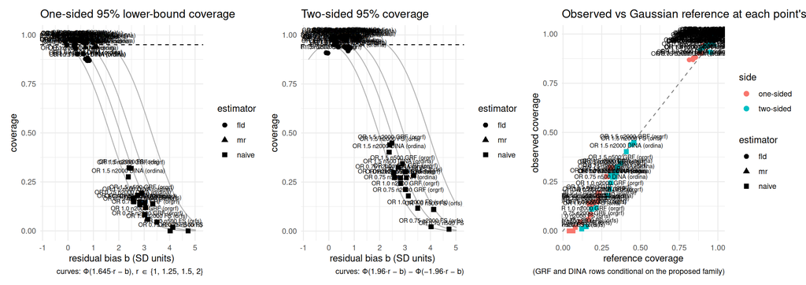

Hhat: bias against coverage on the log-OR scale, one point per estimator per cell x identifier. (GRF and DINA rows conditional on the proposed family)

```r
DS$cell_id <- paste(DS$cell, DS$identifier)
pH <- fs_plot_bias_coverage(within(DS[DS$block == "H", ], cell <- cell_id), side = "lower") +
  ggplot2::labs(caption = COND)
ggsave(file.path(out_dir, "fig_or_bias_coverage_display_H.png"), pH, width = 13, height = 4.6, dpi = 130)
pH
```

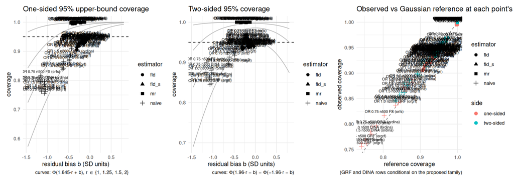

Hhat^c: bias against coverage on the log-OR scale, one point per estimator per cell x identifier; field-s through the renamed copy. (GRF and DINA rows conditional on the proposed family)

```r
pC <- fs_plot_bias_coverage(within(DS[DS$block == "Hc", ], cell <- cell_id), side = "upper") +
  ggplot2::labs(caption = COND)
ggsave(file.path(out_dir, "fig_or_bias_coverage_display_Hc.png"), pC, width = 13, height = 4.6, dpi = 130)
pC
```

# 11 The extract

```r
# Rebuilt from EX, not the earlier XX snapshot: the study-comparison block appends its quoted
# rows after XX is taken for the three-identifier table.
X <- do.call(rbind, EX)
num <- X$commit != "committed grid"
X$value[num] <- signif(X$value[num], 8); X$mc_se[num] <- signif(X$mc_se[num], 6)
X$wilson_lo[num] <- signif(X$wilson_lo[num], 6); X$wilson_hi[num] <- signif(X$wilson_hi[num], 6)
write.csv(X, file.path(out_dir, "or_metrics.csv"), row.names = FALSE, na = "")
cols <- c(
"# COLUMNS — or_metrics.csv (campaigns orfs, orgrf, ordina; TASK_actg175_binary_campaign_2026-09-17 §3.2; Stage 3 run under TASK_actg175_or_stage3_2026-09-28)", "",
"Written by `summary_actg175_or.qmd` from the same objects its tables print. The schema of `../continuous/md_dina_metrics.csv` (see `COLUMNS_md_dina.md`) plus a `design` column. One row per design × cell × identifier × block × estimator × metric (× tau for bound-location rows).", "",
"## Columns", "",
"- `campaign`: `orfs`, `orgrf` or `ordina`; `maxeffCons_actg175_or075_seedtab_s1000` for the rows quoted from the committed study grid.",
"- `identifier`: `fs`, `grf` or `dina` — the identifier that produced the row. Every `grf` and `dina` coverage row is coverage of the estimand **conditional on the proposed family**.",
"- `design`: `or075` (the supplement's protective design), `or150` (harm) or `or100` (borderline null: the planted region at the null against a protective complement). All three share the design of record's planted prevalence 14.917% (`sg_quantile` 0.62850, `REPORT_binary_redesign_2026-09-18.md`) and the complement references θ†(Ĥᶜ) 0.6564 / θ‡(Ĥᶜ) 0.6314; they differ only in `target_effect`.",
"- `cell`: `OR 0.75 n500`, `OR 0.75 n2000`, `OR 1.5 n500`, `OR 1.5 n2000`, `OR 1.0 n500`, `OR 1.0 n2000`.",
"- `block`: `H` (the selected subgroup Ĥ), `Hc` (its complement Ĥᶜ), `joint` (the pair), `all` (timing).",
"- `estimator`: `naive` (unadjusted), `oracle`, `mr` (IJ two-term), `fld` (field), `fld_s` (field-s), `bonf_s`, `bonf`, `separate_s`, `calibrated`, `all`.",
"- `metric`: see below. `tau`: the ladder point, on bound-location rows only.",
"- `value`, `mc_se`: the figure and its Monte Carlo SE. For a proportion, `mc_se` is sqrt(p(1-p)/n) and `wilson_lo` / `wilson_hi` are the Wilson 95% interval; for a mean, `mc_se` is SD/sqrt(n) and the Wilson columns are empty.",
"- `n`: the denominator the figure was computed on.",
"- `commit`: the commit that added the cell's combined bundle; `committed grid` for the quoted study rows.", "",
"## Metrics", "",
"- Estimation, per block × estimator: `bias_or` (mean estimate minus target, OR difference), `bias_log` (mean log estimate minus log target), `bias_sd_units` (`bias_log` / SD(log est)), `sd_emp_or`, `sd_emp_log`, `se_mean` (the stored SE, log-OR scale), `se_over_sd` (`se_mean` / SD(log est)), `halfwidth_or`, `margin1_or`.",
"- Coverage, per block × estimator: `cov2` (two-sided, the estimator's own interval) and `cov1_lower` / `cov1_upper` (one-sided on the block's exposed side), each against the row's target — β(Ĥ) for the conditional rows and θ† for the `oracle` row. The harm block additionally carries `cov2_theta_dagger`, `cov1_lower_theta_dagger`, `cov2_theta_ddagger` and `cov1_lower_theta_ddagger`.",
"- Bound location: `share_lower_ge_tau` (Ĥ) and `share_upper_le_tau` (Ĥᶜ) at each `tau`; `bound_mean` and `bound_q05` … `bound_q95`.",
"- Joint: `joint_coverage`, `share_both_bounds`, `cov_H`, `cov_Hc`, `margin_H_or`, `margin_Hc_or`; `gamma_mean`, `gamma_mean_s`, `corr`, `corr_s` under estimator `calibrated`.",
"- `n_nonconvergent_fits` (every block × estimator): declared replicates that are NON-CONVERGENT FOR THAT ESTIMATOR — its point estimate or either two-sided bound is non-finite, or its point estimate is <= 0. Such rows are excluded from that estimator's coverage, location, spread and bound-location statistics, exactly as the committed study's `is.finite(lo) & is.finite(hi)` masks exclude them from coverage, and the count is carried here and as a `non-convergent` column in every table that has an affected row. No row is dropped silently, and no estimator's rows are dropped on another estimator's account. The motivating case is complete separation in an arm of the true region (the study's `.logit_or_ci()` guards only the OVERALL >= 5 events / >= 5 non-events), where the logistic MLE diverges and the Wald interval degenerates to (0, Inf) with a point estimate of order 1e8. **The data recipe is the committed study's, verbatim: every recorded value is exactly what the recorder wrote. This is a consumer-side convention.**",
"- Identification (block `H`, estimator `all`): `declaration_rate`, `mean_size_hhat` (the recorder's `n_sel`), `mean_true_positives` (sensitivity × `n_true`, never |Ĥ|), `sensitivity_mean`, `ppv_mean`, `spec_mean`, `mean_n_true`, `mean_n_family` (MR's kept family K), `mean_admitted_n` (GRF's forest-qualified / DINA's admitted count; NA on FS), `mean_proposed_n` (DINA only), `mean_n_cons_qual` and `mean_band_n` (FS only).",
"- Regime: `p_hat_mean`, `p_hat_share_lt_05`; `sd_btc_over_naive_se` (block `Hc`, estimator `mr`) and `lamsd_over_naive_se` (block `Hc`, estimators `fld` and `fld_s`), all on the log-OR scale.",
"- Display: `display_b`, `display_r`, `display_cov1`, `display_cov1_ref`, `display_cov2`, `display_cov2_ref` from `fs_sim_bias_coverage(scale = \"log\")`.",
"- Timing (block `all`, estimator `all`): `secs_fit_mr_mean` (the fit with MR, all replicates), `secs_id_mean` (identification inside forestsearch()), `secs_field_mean` and `secs_complement_mean` (declared replicates). `fit_mr_secs` CONTAINS the other three, which are never summed.",
"- Quoted study rows: `study_declaration_rate` and `study_cov2_theta_dagger` — the committed study's detection rate and two-sided coverage of θ† under ITS rule (`maxeffCons`, ε 0.10), IJ intervals only, 1,000 replicates per cell. Read from its grid, never recomputed.", "",
"## Scale convention", "",
"Every estimate, bound and threshold is an **odds ratio**; `adverse_outcome = TRUE`, so **OR > 1 is harm** and no orientation flip is applied anywhere. Two scales coexist and are never mixed (`R/fs_mr_inference.R:480–488`): the **effect** scale (the OR) carries every estimate and bound, and the **working** scale (the log-OR) carries the stored Wald and IJ SEs, the field's `lambda_mean` / `se_field` and the Λ* quantiles. So every bias in SD units, every SE/SD and every regime ratio here is computed on the log-OR scale, while `bias_or`, `halfwidth_or`, `margin*_or` and the bound columns are ORs.", "",
"## Reading convention", "",
"Bounds are read by **location** against the ladder τ = 0.7, 0.8, 0.9, 1.0, 1.25, 1.5, 2.0, never as significance at OR = 1: on Ĥ, a one-sided 95% lower bound at or above τ reads \"harm of at least τ\"; on Ĥᶜ, a one-sided 95% upper bound at or below τ reads \"harm of at most τ\".", "",
"## Conditional-family reading", "",
"GRF's and DINA's candidate families are generated from fitted surfaces, so the fixed-family condition does not hold for them: **every `grf` and `dina` coverage row is coverage of the estimand conditional on the proposed family.** FS's family is the prespecified cut grid. Comparisons across the three identifiers are descriptive: the identifier, the family construction and the set of detected replicates all differ, so rows are read side by side and never ranked.")
writeLines(cols, file.path(out_dir, "COLUMNS_or.md"))
cat(sprintf("extract: %d rows (%d fs, %d grf, %d dina) -> %s ; %s\n", nrow(X),
            sum(X$identifier == "fs"), sum(X$identifier == "grf"), sum(X$identifier == "dina"),
            file.path(out_dir, "or_metrics.csv"), file.path(out_dir, "COLUMNS_or.md")))
```

```
extract: 5814 rows (1938 fs, 1938 grf, 1938 dina) -> ./or_metrics.csv ; ./COLUMNS_or.md
```